# ANOVA test for score

Geiser C. Challco geiser@alumni.usp.br

- ANOVA: score ~ time
  - Data Preparation
  - Summary Statistics
  - ANOVA Computation
  - PairWise Computation
- ANOVA: score ~ time*gender + Error(id/time)
  - Data Preparation
    - Check assumptions: Identifying Outliers
    - Check assumptions: Normality Test
    - Summary Statistics
  - ANOVA Computation
  - ANOVA Computation after removing non.normal data
  - PairWise Computation
  - PairWise Computation after removing non.normal data
- ANOVA: score ~ time*localizacao + Error(id/time)
  - Data Preparation
    - Check assumptions: Identifying Outliers
    - Check assumptions: Normality Test
    - Summary Statistics
  - ANOVA Computation
  - ANOVA Computation after removing non.normal data
  - PairWise Computation
  - PairWise Computation after removing non.normal data
- ANOVA: score ~ time*regiao + Error(id/time)
  - Data Preparation
    - Check assumptions: Identifying Outliers
    - Check assumptions: Normality Test
    - Summary Statistics
  - ANOVA Computation
  - ANOVA Computation after removing non.normal data
  - PairWise Computation
  - PairWise Computation after removing non.normal data
- ANOVA: score ~ time*porte + Error(id/time)
  - Data Preparation
    - Check assumptions: Identifying Outliers
    - Check assumptions: Normality Test
    - Summary Statistics
  - ANOVA Computation
  - ANOVA Computation after removing non.normal data
  - PairWise Computation
  - PairWise Computation after removing non.normal data

```r
dat <- read_excel("../data/data.xlsx", sheet = "alunos_ef59")

escolas <- read_excel("../data/data.xlsx", sheet = "escolas")
edat <- merge(dat, escolas, by = "cod_escola", all.x = T)
```

# ANOVA: score ~ time

## Data Preparation

```r
data <- edat[,c("aluno_id","ciclo","score")]
data <- data[data$ciclo %in% c("Segundo Ciclo","Terceiro Ciclo"),]
data$ciclo <- factor(data$ciclo, c("Segundo Ciclo","Terceiro Ciclo"))
data <- unique(data)

wdat <- spread(data, ciclo, score)
wdat <- wdat[complete.cases(wdat),]
colnames(wdat) <- c("id","c2","c3")

ldat <- gather(wdat, key = time, value = score, c2,c3) %>%
  convert_as_factor(id, time)
ldat <- rshinystatistics::remove_group_data(ldat, "score", "time", n.limit = 30)
```

## Summary Statistics

```r
(sdat <- ldat %>% group_by(time) %>%
   get_summary_stats(score, type = "mean_sd"))
```

```
## # A tibble: 2 × 5
##   time  variable     n  mean    sd
##   <fct> <fct>    <dbl> <dbl> <dbl>
## 1 c2    score     4042  1.73 0.299
## 2 c3    score     4042  1.76 0.327
```

| time | variable | n | mean | sd |
| --- | --- | --- | --- | --- |
| c2 | score | 4042 | 1.734 | 0.299 |
| c3 | score | 4042 | 1.758 | 0.327 |

## ANOVA Computation

```r
(res.aov <- anova_test(ldat, dv = score, wid = id, within = time))
```

```
## ANOVA Table (type III tests)
##
##   Effect DFn  DFd      F        p p<.05   ges
## 1   time   1 4041 14.013 0.000184     * 0.001
```

## PairWise Computation

```r
(pwc <- ldat %>% emmeans_test(score ~ time, detailed = T, p.adjust.method = "bonferroni"))
```

```
## # A tibble: 1 × 14
##   term  .y.   group1 group2 null.value estimate      se    df conf.low conf.high
## * <chr> <chr> <chr>  <chr>       <dbl>    <dbl>   <dbl> <dbl>    <dbl>     <dbl>
## 1 time  score c2     c3              0  -0.0241 0.00696  8082  -0.0377   -0.0104
## # ℹ 4 more variables: statistic <dbl>, p <dbl>, p.adj <dbl>, p.adj.signif <chr>
```

| term | .y. | group1 | group2 | null.value | estimate | se | df | conf.low | conf.high | statistic | p | p.adj | p.adj.signif |
| --- | --- | --- | --- | --- | --- | --- | --- | --- | --- | --- | --- | --- | --- |
| time | score | c2 | c3 | 0 | -0.024 | 0.007 | 8082 | -0.038 | -0.01 | -3.457 | 0.001 | 0.001 | *** |

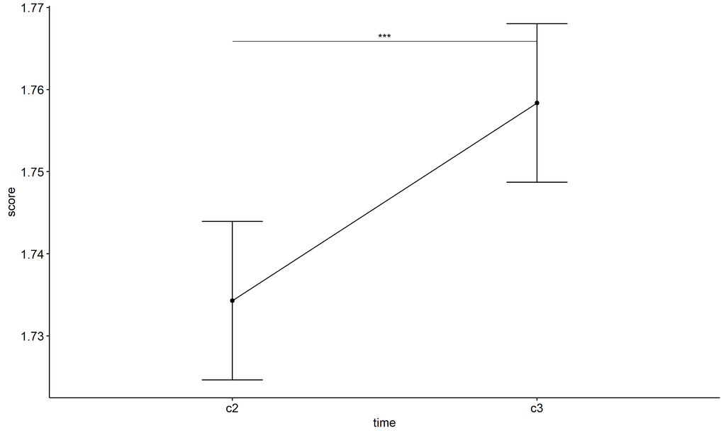

```r
pwc <- add_xy_position(pwc, x = "time", fun = "mean_se")
ggline(get_emmeans(pwc), x = "time", y = "emmean", ylab = "score") +
  geom_errorbar(aes(ymin = conf.low, ymax = conf.high), width = 0.2) +
  stat_pvalue_manual(pwc, hide.ns = T, tip.length = F)
```

# ANOVA: score ~ time*gender + Error(id/time)

## Data Preparation

```r
data <- edat[,c("aluno_id","gender","ciclo","score")]
data <- data[data$ciclo %in% c("Segundo Ciclo","Terceiro Ciclo"),]
data$ciclo <- factor(data$ciclo, c("Segundo Ciclo","Terceiro Ciclo"))
data <- unique(data)

wdat <- spread(data, ciclo, score)
wdat <- wdat[complete.cases(wdat),]
colnames(wdat) <- c("id","gender","c2","c3")

ldat <- gather(wdat, key = time, value = score, c2,c3) %>%
  convert_as_factor(id, time)
ldat <- remove_group_data(ldat, "score", c("time", "gender"), n.limit = 30)
ldat$gender <- factor(ldat$gender, sort(unique(ldat$gender)))
```

### Check assumptions: Identifying Outliers

```r
outliers <- identify_outliers(group_by(ldat, time, gender), score)
(outliers <- outliers[outliers$is.extreme == T,])
```

```
## # A tibble: 3 × 6
##   gender time  id                   score is.outlier is.extreme
##   <fct>  <fct> <fct>                <dbl> <lgl>      <lgl>
## 1 Female c2    oEDVJwdVHdc8vvUBo2jy     3 TRUE       TRUE
## 2 Female c2    u1zil2OzxQVXB2KwkuTr     3 TRUE       TRUE
## 3 Female c3    ygluKcF3wOKKl3jfvWGo     3 TRUE       TRUE
```

| gender | time | id | score | is.outlier | is.extreme |
| --- | --- | --- | --- | --- | --- |
| Female | c2 | oEDVJwdVHdc8vvUBo2jy | 3 | TRUE | TRUE |
| Female | c2 | u1zil2OzxQVXB2KwkuTr | 3 | TRUE | TRUE |
| Female | c3 | ygluKcF3wOKKl3jfvWGo | 3 | TRUE | TRUE |

### Check assumptions: Normality Test

```r
(normality.df <- normality.test.per.groups(ldat, "score", c("time", "gender")))
```

```
##     var variable time gender    n  skewness   kurtosis symmetry statistic
## 1 score    score   c2 Female 1876 0.6062370 0.40697035       NO 109.31421
## 2 score    score   c2   Male 1917 0.6919024 0.48266903       NO 140.60610
## 3 score    score   c3 Female 1876 0.5631486 0.02930016       NO  87.57704
## 4 score    score   c3   Male 1917 0.6993832 0.22406696       NO 133.45175
##       method p p.signif normality
## 1 D'Agostino 0     ****         -
## 2 D'Agostino 0     ****         -
## 3 D'Agostino 0     ****         -
## 4 D'Agostino 0     ****         -
```

| var | variable | time | gender | n | skewness | kurtosis | symmetry | statistic | method | p | p.signif | normality |
| --- | --- | --- | --- | --- | --- | --- | --- | --- | --- | --- | --- | --- |
| score | score | c2 | Female | 1876 | 0.606 | 0.407 | NO | 109.314 | D’Agostino | 0 | **** | - |
| score | score | c2 | Male | 1917 | 0.692 | 0.483 | NO | 140.606 | D’Agostino | 0 | **** | - |
| score | score | c3 | Female | 1876 | 0.563 | 0.029 | NO | 87.577 | D’Agostino | 0 | **** | - |
| score | score | c3 | Male | 1917 | 0.699 | 0.224 | NO | 133.452 | D’Agostino | 0 | **** | - |

```r
(non.ids <- unique(do.call(
  c, lapply(which(normality.df$normality == 'NO'), FUN = function(i) {
  idx = which(ldat$time == normality.df$time[i] &
                ldat$gender == normality.df$gender[i])
  getNonNormal(ldat$"score"[idx], ldat$id[idx])
}))))
```

```r
if (length(non.ids) > 0)
  ldat2 <- ldat[!ldat$id %in% non.ids,]
```

### Summary Statistics

```r
(sdat <- ldat %>% group_by(time, gender) %>%
   get_summary_stats(score, type = "mean_sd"))
```

```
## # A tibble: 4 × 6
##   gender time  variable     n  mean    sd
##   <fct>  <fct> <fct>    <dbl> <dbl> <dbl>
## 1 Female c2    score     1876  1.76 0.305
## 2 Male   c2    score     1917  1.71 0.294
## 3 Female c3    score     1876  1.78 0.33
## 4 Male   c3    score     1917  1.74 0.322
```

| gender | time | variable | n | mean | sd |
| --- | --- | --- | --- | --- | --- |
| Female | c2 | score | 1876 | 1.758 | 0.305 |
| Male | c2 | score | 1917 | 1.711 | 0.294 |
| Female | c3 | score | 1876 | 1.779 | 0.330 |
| Male | c3 | score | 1917 | 1.738 | 0.322 |

```r
if (length(non.ids) > 0)
  (sdat <- ldat2 %>% group_by(time, gender) %>%
      get_summary_stats(score, type = "mean_sd"))
```

| gender | time | variable | n | mean | sd |
| --- | --- | --- | --- | --- | --- |
| Female | c2 | score | 1876 | 1.758 | 0.305 |
| Male | c2 | score | 1917 | 1.711 | 0.294 |
| Female | c3 | score | 1876 | 1.779 | 0.330 |
| Male | c3 | score | 1917 | 1.738 | 0.322 |

## ANOVA Computation

```r
(res.aov <- anova_test(ldat, dv = score, wid = id, between = gender, within = time))
```

```
## ANOVA Table (type III tests)
##
##        Effect DFn  DFd      F        p p<.05      ges
## 1      gender   1 3791 33.383 8.18e-09     * 5.00e-03
## 2        time   1 3791 13.257 2.75e-04     * 1.00e-03
## 3 gender:time   1 3791  0.171 6.80e-01       1.93e-05
```

## ANOVA Computation after removing non.normal data

```r
if (length(non.ids) > 0)
  (res.aov2 <- anova_test(ldat2, dv = score, wid = id, between = gender , within = time))
```

## PairWise Computation

```r
(pwc <- ldat %>% group_by(time) %>%
   emmeans_test(score ~ gender, detailed = T, p.adjust.method = "bonferroni"))
```

```
## # A tibble: 2 × 15
##   time  term   .y.   group1 group2 null.value estimate     se    df conf.low
## * <fct> <chr>  <chr> <chr>  <chr>       <dbl>    <dbl>  <dbl> <dbl>    <dbl>
## 1 c2    gender score Female Male            0   0.0471 0.0102  7582   0.0272
## 2 c3    gender score Female Male            0   0.0416 0.0102  7582   0.0217
## # ℹ 5 more variables: conf.high <dbl>, statistic <dbl>, p <dbl>, p.adj <dbl>,
## #   p.adj.signif <chr>
```

| time | term | .y. | group1 | group2 | null.value | estimate | se | df | conf.low | conf.high | statistic | p | p.adj | p.adj.signif |
| --- | --- | --- | --- | --- | --- | --- | --- | --- | --- | --- | --- | --- | --- | --- |
| c2 | gender | score | Female | Male | 0 | 0.047 | 0.01 | 7582 | 0.027 | 0.067 | 4.638 | 0 | 0 | **** |
| c3 | gender | score | Female | Male | 0 | 0.042 | 0.01 | 7582 | 0.022 | 0.062 | 4.097 | 0 | 0 | **** |

```r
(emms <- get_emmeans(pwc))
```

```
## # A tibble: 4 × 8
##   time  gender emmean      se    df conf.low conf.high method
##   <fct> <fct>   <dbl>   <dbl> <dbl>    <dbl>     <dbl> <chr>
## 1 c2    Female   1.76 0.00722  7582     1.74      1.77 Emmeans test
## 2 c2    Male     1.71 0.00715  7582     1.70      1.72 Emmeans test
## 3 c3    Female   1.78 0.00722  7582     1.77      1.79 Emmeans test
## 4 c3    Male     1.74 0.00715  7582     1.72      1.75 Emmeans test
```

| time | gender | emmean | se | df | conf.low | conf.high | method |
| --- | --- | --- | --- | --- | --- | --- | --- |
| c2 | Female | 1.758 | 0.007 | 7582 | 1.744 | 1.772 | Emmeans test |
| c2 | Male | 1.711 | 0.007 | 7582 | 1.697 | 1.725 | Emmeans test |
| c3 | Female | 1.779 | 0.007 | 7582 | 1.765 | 1.794 | Emmeans test |
| c3 | Male | 1.738 | 0.007 | 7582 | 1.724 | 1.752 | Emmeans test |

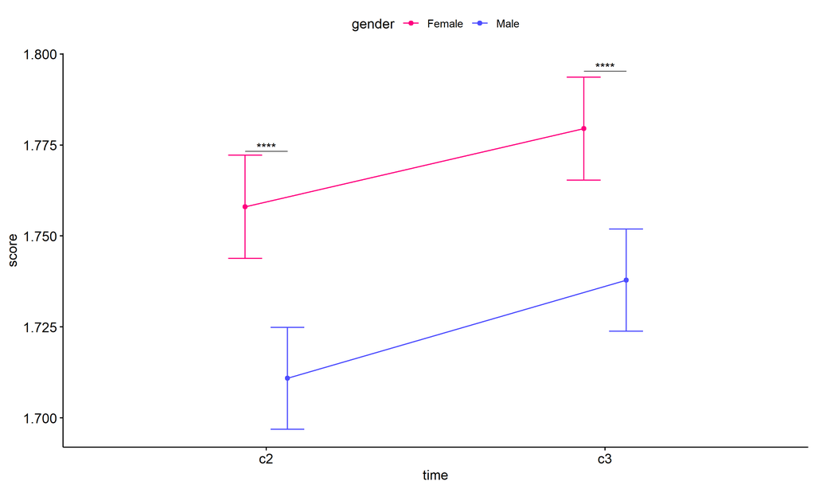

```r
pwc <- add_xy_position(pwc, x = "time", fun = "mean_se", dodge = 0.25)
pd <- position_dodge(width = 0.25)
ggline(emms, x = "time", y = "emmean", color = "gender",
       palette = c("#FF007F","#4D4DFF"),
       position = pd, ylab = "score") +
  geom_errorbar(aes(ymin = conf.low, ymax = conf.high, color = gender),
                position = pd, width = 0.2) +
  stat_pvalue_manual(pwc, hide.ns = T, tip.length = F, linetype = 1)
```

```r
(pwc <- ldat %>% group_by(gender) %>%
    emmeans_test(score ~ time, detailed = T, p.adjust.method = "bonferroni"))
```

```
## # A tibble: 2 × 15
##   gender term  .y.   group1 group2 null.value estimate     se    df conf.low
## * <fct>  <chr> <chr> <chr>  <chr>       <dbl>    <dbl>  <dbl> <dbl>    <dbl>
## 1 Female time  score c2     c3              0  -0.0215 0.0102  7582  -0.0415
## 2 Male   time  score c2     c3              0  -0.0270 0.0101  7582  -0.0468
## # ℹ 5 more variables: conf.high <dbl>, statistic <dbl>, p <dbl>, p.adj <dbl>,
## #   p.adj.signif <chr>
```

| gender | term | .y. | group1 | group2 | null.value | estimate | se | df | conf.low | conf.high | statistic | p | p.adj | p.adj.signif |
| --- | --- | --- | --- | --- | --- | --- | --- | --- | --- | --- | --- | --- | --- | --- |
| Female | time | score | c2 | c3 | 0 | -0.021 | 0.01 | 7582 | -0.041 | -0.001 | -2.102 | 0.036 | 0.036 | * |
| Male | time | score | c2 | c3 | 0 | -0.027 | 0.01 | 7582 | -0.047 | -0.007 | -2.669 | 0.008 | 0.008 | ** |

```r
(emms <- get_emmeans(pwc))
```

```
## # A tibble: 4 × 8
##   gender time  emmean      se    df conf.low conf.high method
##   <fct>  <fct>  <dbl>   <dbl> <dbl>    <dbl>     <dbl> <chr>
## 1 Female c2      1.76 0.00722  7582     1.74      1.77 Emmeans test
## 2 Female c3      1.78 0.00722  7582     1.77      1.79 Emmeans test
## 3 Male   c2      1.71 0.00715  7582     1.70      1.72 Emmeans test
## 4 Male   c3      1.74 0.00715  7582     1.72      1.75 Emmeans test
```

| gender | time | emmean | se | df | conf.low | conf.high | method |
| --- | --- | --- | --- | --- | --- | --- | --- |
| Female | c2 | 1.758 | 0.007 | 7582 | 1.744 | 1.772 | Emmeans test |
| Female | c3 | 1.779 | 0.007 | 7582 | 1.765 | 1.794 | Emmeans test |
| Male | c2 | 1.711 | 0.007 | 7582 | 1.697 | 1.725 | Emmeans test |
| Male | c3 | 1.738 | 0.007 | 7582 | 1.724 | 1.752 | Emmeans test |

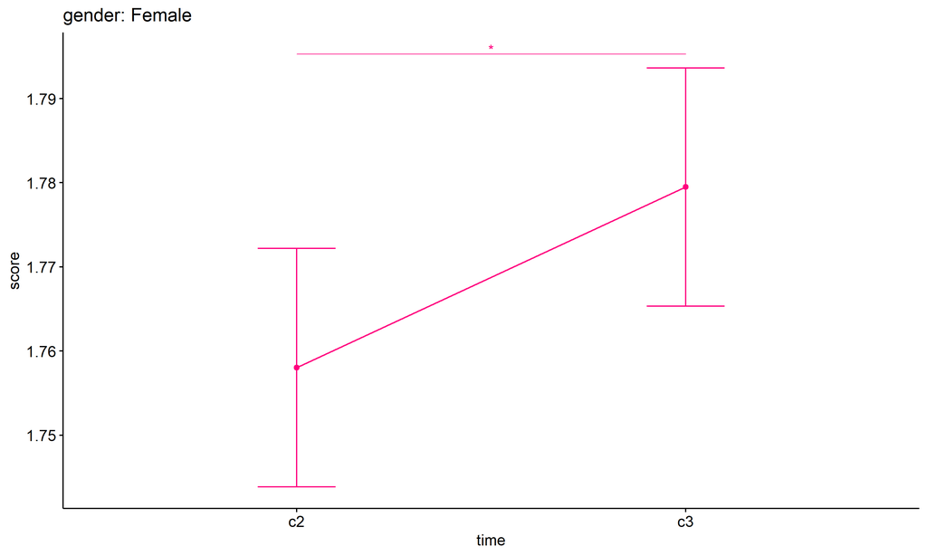

```r
emms.gg <- emms[which(emms$gender == "Female"),]
if (nrow(emms.gg) > 0)
  ggline(emms.gg, x = "time", y = "emmean", color = "#FF007F", ylab = "score") +
    geom_errorbar(aes(ymin = conf.low, ymax = conf.high),
                  width = 0.2, color = "#FF007F") +
    stat_pvalue_manual(
      add_xy_position(pwc[which(pwc$gender == "Female"),],
                      x = "time", fun = "mean_se"),
      hide.ns = T, color = "#FF007F", tip.length = F) +
    labs(title = "gender: Female")+
    theme(legend.text = element_blank())
```

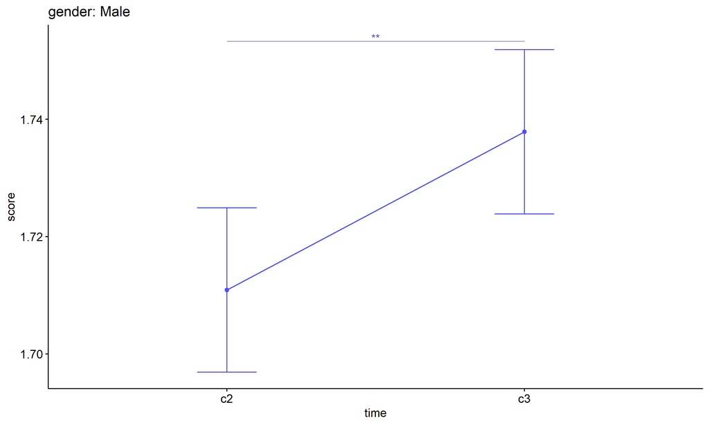

```r
emms.gg <- emms[which(emms$gender == "Male"),]
if (nrow(emms.gg) > 0)
  ggline(emms.gg, x = "time", y = "emmean", color = "#4D4DFF", ylab = "score") +
    geom_errorbar(aes(ymin = conf.low, ymax = conf.high),
                  width = 0.2, color = "#4D4DFF") +
    stat_pvalue_manual(
      add_xy_position(pwc[which(pwc$gender == "Male"),],
                      x = "time", fun = "mean_se"),
      hide.ns = T, color = "#4D4DFF", tip.length = F) +
    labs(title = "gender: Male")+
    theme(legend.text = element_blank())
```

## PairWise Computation after removing non.normal data

```r
if (length(non.ids) > 0)
  (pwc2 <- ldat2 %>% group_by(time) %>%
     emmeans_test(score ~ gender, detailed = T, p.adjust.method = "bonferroni"))
```

```r
if (length(non.ids) > 0)
  (emms2 <- get_emmeans(pwc2))
```

```r
if (length(non.ids) > 0) {
  pwc2 <- add_xy_position(pwc2, x = "time", fun = "mean_se", dodge = 0.25)
  pd2 <- position_dodge(width = 0.25)

  ggline(emms2, x = "time", y = "emmean", color = "gender",
         palette = c("#FF007F","#4D4DFF"),
         position = pd, ylab = "score") +
    geom_errorbar(aes(ymin = conf.low, ymax = conf.high, color = gender),
                position = pd, width = 0.2) +
    stat_pvalue_manual(pwc2, hide.ns = T, tip.length = F, linetype = 1)
}
```

```r
if (length(non.ids) > 0)
  (pwc2 <- ldat2 %>% group_by(gender) %>%
     emmeans_test(score ~ time, detailed = T, p.adjust.method = "bonferroni"))
```

```r
if (length(non.ids) > 0)
  (emms2 <- get_emmeans(pwc2))
```

```r
if (length(non.ids) > 0) {
  emms.gg <- emms2[which(emms2$gender == "Female"),]
  if (nrow(emms.gg) > 0)
    ggline(emms.gg, x = "time", y = "emmean", color = "#FF007F", ylab = "score") +
    geom_errorbar(aes(ymin = conf.low, ymax = conf.high),
                  width = 0.2, color = "#FF007F") +
    stat_pvalue_manual(
      add_xy_position(pwc[which(pwc$gender == "Female"),],
                      x = "time", fun = "mean_se"),
      hide.ns = T, color = "#FF007F", tip.length = F) +
    labs(title = "gender: Female") +
    theme(legend.text = element_blank())
}
```

```r
if (length(non.ids) > 0) {
  emms.gg <- emms2[which(emms2$gender == "Male"),]
  if (nrow(emms.gg) > 0)
    ggline(emms.gg, x = "time", y = "emmean", color = "#4D4DFF", ylab = "score") +
    geom_errorbar(aes(ymin = conf.low, ymax = conf.high),
                  width = 0.2, color = "#4D4DFF") +
    stat_pvalue_manual(
      add_xy_position(pwc[which(pwc$gender == "Male"),],
                      x = "time", fun = "mean_se"),
      hide.ns = T, color = "#4D4DFF", tip.length = F) +
    labs(title = "gender: Male") +
    theme(legend.text = element_blank())
}
```

# ANOVA: score ~ time*localizacao + Error(id/time)

## Data Preparation

```r
data <- edat[,c("aluno_id","localizacao","ciclo","score")]
data <- data[data$ciclo %in% c("Segundo Ciclo","Terceiro Ciclo"),]
data$ciclo <- factor(data$ciclo, c("Segundo Ciclo","Terceiro Ciclo"))
data <- unique(data)

wdat <- spread(data, ciclo, score)
wdat <- wdat[complete.cases(wdat),]
colnames(wdat) <- c("id","localizacao","c2","c3")

ldat <- gather(wdat, key = time, value = score, c2,c3) %>%
  convert_as_factor(id, time)
ldat <- remove_group_data(ldat, "score", c("time", "localizacao"), n.limit = 30)
ldat$localizacao <- factor(ldat$localizacao, sort(unique(ldat$localizacao)))
```

### Check assumptions: Identifying Outliers

```r
outliers <- identify_outliers(group_by(ldat, time, localizacao), score)
(outliers <- outliers[outliers$is.extreme == T,])
```

```
## # A tibble: 0 × 6
## # ℹ 6 variables: localizacao <fct>, time <fct>, id <fct>, score <dbl>,
## #   is.outlier <lgl>, is.extreme <lgl>
```

| localizacao | time | id | score | is.outlier | is.extreme |
| --- | --- | --- | --- | --- | --- |

### Check assumptions: Normality Test

```r
(normality.df <- normality.test.per.groups(ldat, "score", c("time", "localizacao")))
```

```
##     var variable time localizacao    n  skewness   kurtosis symmetry statistic
## 1 score    score   c2       Rural  701 0.6809330 0.34724634       NO  49.47610
## 2 score    score   c2      Urbana 3341 0.6221721 0.40894566       NO 201.45277
## 3 score    score   c3       Rural  701 0.6907520 0.24227268       NO  49.20172
## 4 score    score   c3      Urbana 3341 0.6198887 0.06104477       NO 183.89690
##       method            p p.signif normality
## 1 D'Agostino 1.804690e-11     ****         -
## 2 D'Agostino 0.000000e+00     ****         -
## 3 D'Agostino 2.070055e-11     ****         -
## 4 D'Agostino 0.000000e+00     ****         -
```

| var | variable | time | localizacao | n | skewness | kurtosis | symmetry | statistic | method | p | p.signif | normality |
| --- | --- | --- | --- | --- | --- | --- | --- | --- | --- | --- | --- | --- |
| score | score | c2 | Rural | 701 | 0.681 | 0.347 | NO | 49.476 | D’Agostino | 0 | **** | - |
| score | score | c2 | Urbana | 3341 | 0.622 | 0.409 | NO | 201.453 | D’Agostino | 0 | **** | - |
| score | score | c3 | Rural | 701 | 0.691 | 0.242 | NO | 49.202 | D’Agostino | 0 | **** | - |
| score | score | c3 | Urbana | 3341 | 0.620 | 0.061 | NO | 183.897 | D’Agostino | 0 | **** | - |

```r
(non.ids <- unique(do.call(
  c, lapply(which(normality.df$normality == 'NO'), FUN = function(i) {
  idx = which(ldat$time == normality.df$time[i] &
                ldat$localizacao == normality.df$localizacao[i])
  getNonNormal(ldat$"score"[idx], ldat$id[idx])
}))))
```

```r
if (length(non.ids) > 0)
  ldat2 <- ldat[!ldat$id %in% non.ids,]
```

### Summary Statistics

```r
(sdat <- ldat %>% group_by(time, localizacao) %>%
   get_summary_stats(score, type = "mean_sd"))
```

```
## # A tibble: 4 × 6
##   localizacao time  variable     n  mean    sd
##   <fct>       <fct> <fct>    <dbl> <dbl> <dbl>
## 1 Rural       c2    score      701  1.75 0.319
## 2 Urbana      c2    score     3341  1.73 0.294
## 3 Rural       c3    score      701  1.76 0.327
## 4 Urbana      c3    score     3341  1.76 0.327
```

| localizacao | time | variable | n | mean | sd |
| --- | --- | --- | --- | --- | --- |
| Rural | c2 | score | 701 | 1.748 | 0.319 |
| Urbana | c2 | score | 3341 | 1.731 | 0.294 |
| Rural | c3 | score | 701 | 1.761 | 0.327 |
| Urbana | c3 | score | 3341 | 1.758 | 0.327 |

```r
if (length(non.ids) > 0)
  (sdat <- ldat2 %>% group_by(time, localizacao) %>%
      get_summary_stats(score, type = "mean_sd"))
```

| localizacao | time | variable | n | mean | sd |
| --- | --- | --- | --- | --- | --- |
| Rural | c2 | score | 701 | 1.748 | 0.319 |
| Urbana | c2 | score | 3341 | 1.731 | 0.294 |
| Rural | c3 | score | 701 | 1.761 | 0.327 |
| Urbana | c3 | score | 3341 | 1.758 | 0.327 |

## ANOVA Computation

```r
(res.aov <- anova_test(ldat, dv = score, wid = id, between = localizacao, within = time))
```

```
## ANOVA Table (type III tests)
##
##             Effect DFn  DFd     F     p p<.05      ges
## 1      localizacao   1 4040 0.991 0.319       1.41e-04
## 2             time   1 4040 5.327 0.021     * 5.62e-04
## 3 localizacao:time   1 4040 0.650 0.420       6.86e-05
```

## ANOVA Computation after removing non.normal data

```r
if (length(non.ids) > 0)
  (res.aov2 <- anova_test(ldat2, dv = score, wid = id, between = localizacao , within = time))
```

## PairWise Computation

```r
(pwc <- ldat %>% group_by(time) %>%
   emmeans_test(score ~ localizacao, detailed = T, p.adjust.method = "bonferroni"))
```

```
## # A tibble: 2 × 15
##   time  term       .y.   group1 group2 null.value estimate     se    df conf.low
## * <fct> <chr>      <chr> <chr>  <chr>       <dbl>    <dbl>  <dbl> <dbl>    <dbl>
## 1 c2    localizac… score Rural  Urbana          0  0.0167  0.0130  8080 -0.00884
## 2 c3    localizac… score Rural  Urbana          0  0.00296 0.0130  8080 -0.0225
## # ℹ 5 more variables: conf.high <dbl>, statistic <dbl>, p <dbl>, p.adj <dbl>,
## #   p.adj.signif <chr>
```

| time | term | .y. | group1 | group2 | null.value | estimate | se | df | conf.low | conf.high | statistic | p | p.adj | p.adj.signif |
| --- | --- | --- | --- | --- | --- | --- | --- | --- | --- | --- | --- | --- | --- | --- |
| c2 | localizacao | score | Rural | Urbana | 0 | 0.017 | 0.013 | 8080 | -0.009 | 0.042 | 1.280 | 0.20 | 0.20 | ns |
| c3 | localizacao | score | Rural | Urbana | 0 | 0.003 | 0.013 | 8080 | -0.023 | 0.028 | 0.228 | 0.82 | 0.82 | ns |

```r
(emms <- get_emmeans(pwc))
```

```
## # A tibble: 4 × 8
##   time  localizacao emmean      se    df conf.low conf.high method
##   <fct> <fct>        <dbl>   <dbl> <dbl>    <dbl>     <dbl> <chr>
## 1 c2    Rural         1.75 0.0118   8080     1.72      1.77 Emmeans test
## 2 c2    Urbana        1.73 0.00542  8080     1.72      1.74 Emmeans test
## 3 c3    Rural         1.76 0.0118   8080     1.74      1.78 Emmeans test
## 4 c3    Urbana        1.76 0.00542  8080     1.75      1.77 Emmeans test
```

| time | localizacao | emmean | se | df | conf.low | conf.high | method |
| --- | --- | --- | --- | --- | --- | --- | --- |
| c2 | Rural | 1.748 | 0.012 | 8080 | 1.725 | 1.771 | Emmeans test |
| c2 | Urbana | 1.731 | 0.005 | 8080 | 1.721 | 1.742 | Emmeans test |
| c3 | Rural | 1.761 | 0.012 | 8080 | 1.738 | 1.784 | Emmeans test |
| c3 | Urbana | 1.758 | 0.005 | 8080 | 1.747 | 1.768 | Emmeans test |

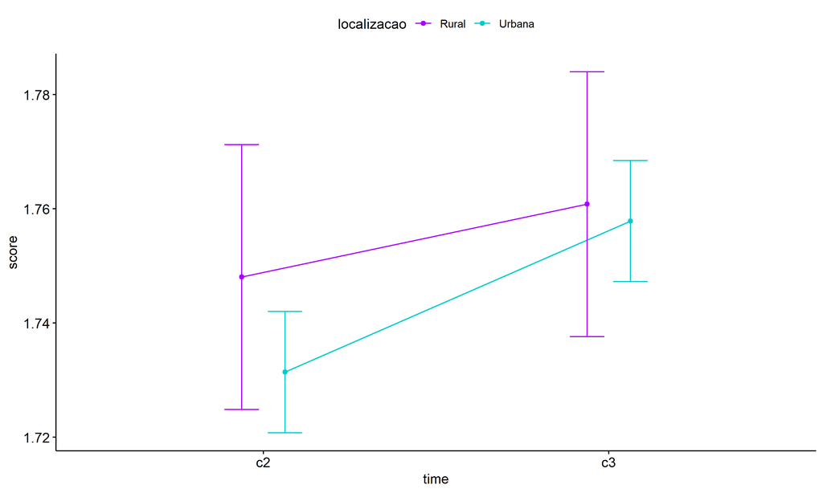

```r
pwc <- add_xy_position(pwc, x = "time", fun = "mean_se", dodge = 0.25)
pd <- position_dodge(width = 0.25)
ggline(emms, x = "time", y = "emmean", color = "localizacao",
       palette = c("#AA00FF","#00CCCC"),
       position = pd, ylab = "score") +
  geom_errorbar(aes(ymin = conf.low, ymax = conf.high, color = localizacao),
                position = pd, width = 0.2) +
  stat_pvalue_manual(pwc, hide.ns = T, tip.length = F, linetype = 1)
```

```r
(pwc <- ldat %>% group_by(localizacao) %>%
    emmeans_test(score ~ time, detailed = T, p.adjust.method = "bonferroni"))
```

```
## # A tibble: 2 × 15
##   localizacao term  .y.   group1 group2 null.value estimate      se    df
## * <fct>       <chr> <chr> <chr>  <chr>       <dbl>    <dbl>   <dbl> <dbl>
## 1 Rural       time  score c2     c3              0  -0.0128 0.0167   8080
## 2 Urbana      time  score c2     c3              0  -0.0265 0.00766  8080
## # ℹ 6 more variables: conf.low <dbl>, conf.high <dbl>, statistic <dbl>,
## #   p <dbl>, p.adj <dbl>, p.adj.signif <chr>
```

| localizacao | term | .y. | group1 | group2 | null.value | estimate | se | df | conf.low | conf.high | statistic | p | p.adj | p.adj.signif |
| --- | --- | --- | --- | --- | --- | --- | --- | --- | --- | --- | --- | --- | --- | --- |
| Rural | time | score | c2 | c3 | 0 | -0.013 | 0.017 | 8080 | -0.046 | 0.020 | -0.763 | 0.445 | 0.445 | ns |
| Urbana | time | score | c2 | c3 | 0 | -0.026 | 0.008 | 8080 | -0.041 | -0.011 | -3.453 | 0.001 | 0.001 | *** |

```r
(emms <- get_emmeans(pwc))
```

```
## # A tibble: 4 × 8
##   localizacao time  emmean      se    df conf.low conf.high method
##   <fct>       <fct>  <dbl>   <dbl> <dbl>    <dbl>     <dbl> <chr>
## 1 Rural       c2      1.75 0.0118   8080     1.72      1.77 Emmeans test
## 2 Rural       c3      1.76 0.0118   8080     1.74      1.78 Emmeans test
## 3 Urbana      c2      1.73 0.00542  8080     1.72      1.74 Emmeans test
## 4 Urbana      c3      1.76 0.00542  8080     1.75      1.77 Emmeans test
```

| localizacao | time | emmean | se | df | conf.low | conf.high | method |
| --- | --- | --- | --- | --- | --- | --- | --- |
| Rural | c2 | 1.748 | 0.012 | 8080 | 1.725 | 1.771 | Emmeans test |
| Rural | c3 | 1.761 | 0.012 | 8080 | 1.738 | 1.784 | Emmeans test |
| Urbana | c2 | 1.731 | 0.005 | 8080 | 1.721 | 1.742 | Emmeans test |
| Urbana | c3 | 1.758 | 0.005 | 8080 | 1.747 | 1.768 | Emmeans test |

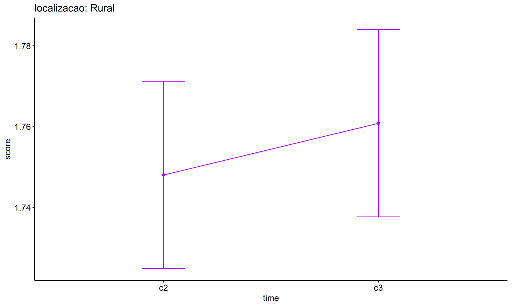

```r
emms.gg <- emms[which(emms$localizacao == "Rural"),]
if (nrow(emms.gg) > 0)
  ggline(emms.gg, x = "time", y = "emmean", color = "#AA00FF", ylab = "score") +
    geom_errorbar(aes(ymin = conf.low, ymax = conf.high),
                  width = 0.2, color = "#AA00FF") +
    stat_pvalue_manual(
      add_xy_position(pwc[which(pwc$localizacao == "Rural"),],
                      x = "time", fun = "mean_se"),
      hide.ns = T, color = "#AA00FF", tip.length = F) +
    labs(title = "localizacao: Rural")+
    theme(legend.text = element_blank())
```

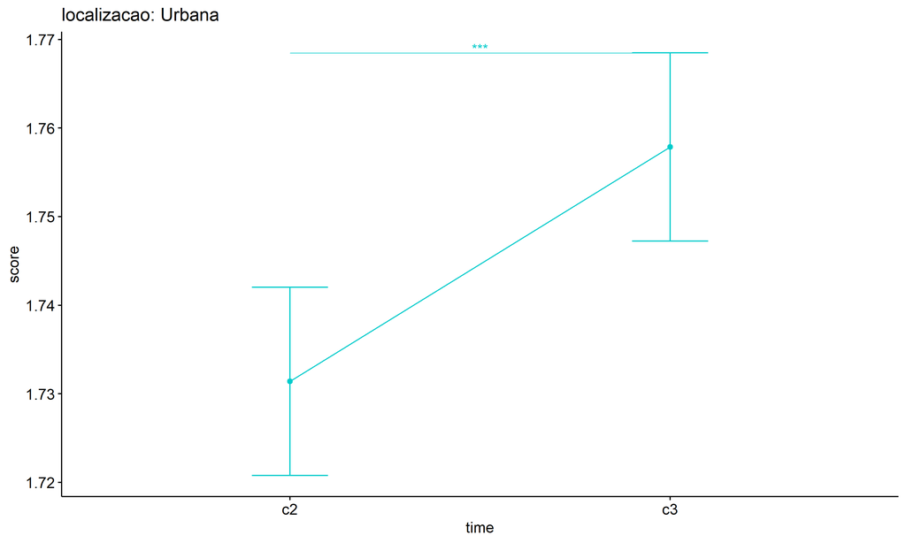

```r
emms.gg <- emms[which(emms$localizacao == "Urbana"),]
if (nrow(emms.gg) > 0)
  ggline(emms.gg, x = "time", y = "emmean", color = "#00CCCC", ylab = "score") +
    geom_errorbar(aes(ymin = conf.low, ymax = conf.high),
                  width = 0.2, color = "#00CCCC") +
    stat_pvalue_manual(
      add_xy_position(pwc[which(pwc$localizacao == "Urbana"),],
                      x = "time", fun = "mean_se"),
      hide.ns = T, color = "#00CCCC", tip.length = F) +
    labs(title = "localizacao: Urbana")+
    theme(legend.text = element_blank())
```

## PairWise Computation after removing non.normal data

```r
if (length(non.ids) > 0)
  (pwc2 <- ldat2 %>% group_by(time) %>%
     emmeans_test(score ~ localizacao, detailed = T, p.adjust.method = "bonferroni"))
```

```r
if (length(non.ids) > 0)
  (emms2 <- get_emmeans(pwc2))
```

```r
if (length(non.ids) > 0) {
  pwc2 <- add_xy_position(pwc2, x = "time", fun = "mean_se", dodge = 0.25)
  pd2 <- position_dodge(width = 0.25)

  ggline(emms2, x = "time", y = "emmean", color = "localizacao",
         palette = c("#AA00FF","#00CCCC"),
         position = pd, ylab = "score") +
    geom_errorbar(aes(ymin = conf.low, ymax = conf.high, color = localizacao),
                position = pd, width = 0.2) +
    stat_pvalue_manual(pwc2, hide.ns = T, tip.length = F, linetype = 1)
}
```

```r
if (length(non.ids) > 0)
  (pwc2 <- ldat2 %>% group_by(localizacao) %>%
     emmeans_test(score ~ time, detailed = T, p.adjust.method = "bonferroni"))
```

```r
if (length(non.ids) > 0)
  (emms2 <- get_emmeans(pwc2))
```

```r
if (length(non.ids) > 0) {
  emms.gg <- emms2[which(emms2$localizacao == "Rural"),]
  if (nrow(emms.gg) > 0)
    ggline(emms.gg, x = "time", y = "emmean", color = "#AA00FF", ylab = "score") +
    geom_errorbar(aes(ymin = conf.low, ymax = conf.high),
                  width = 0.2, color = "#AA00FF") +
    stat_pvalue_manual(
      add_xy_position(pwc[which(pwc$localizacao == "Rural"),],
                      x = "time", fun = "mean_se"),
      hide.ns = T, color = "#AA00FF", tip.length = F) +
    labs(title = "localizacao: Rural") +
    theme(legend.text = element_blank())
}
```

```r
if (length(non.ids) > 0) {
  emms.gg <- emms2[which(emms2$localizacao == "Urbana"),]
  if (nrow(emms.gg) > 0)
    ggline(emms.gg, x = "time", y = "emmean", color = "#00CCCC", ylab = "score") +
    geom_errorbar(aes(ymin = conf.low, ymax = conf.high),
                  width = 0.2, color = "#00CCCC") +
    stat_pvalue_manual(
      add_xy_position(pwc[which(pwc$localizacao == "Urbana"),],
                      x = "time", fun = "mean_se"),
      hide.ns = T, color = "#00CCCC", tip.length = F) +
    labs(title = "localizacao: Urbana") +
    theme(legend.text = element_blank())
}
```

# ANOVA: score ~ time*regiao + Error(id/time)

## Data Preparation

```r
data <- edat[,c("aluno_id","regiao","ciclo","score")]
data <- data[data$ciclo %in% c("Segundo Ciclo","Terceiro Ciclo"),]
data$ciclo <- factor(data$ciclo, c("Segundo Ciclo","Terceiro Ciclo"))
data <- unique(data)

wdat <- spread(data, ciclo, score)
wdat <- wdat[complete.cases(wdat),]
colnames(wdat) <- c("id","regiao","c2","c3")

ldat <- gather(wdat, key = time, value = score, c2,c3) %>%
  convert_as_factor(id, time)
ldat <- remove_group_data(ldat, "score", c("time", "regiao"), n.limit = 30)
ldat$regiao <- factor(ldat$regiao, sort(unique(ldat$regiao)))
```

### Check assumptions: Identifying Outliers

```r
outliers <- identify_outliers(group_by(ldat, time, regiao), score)
(outliers <- outliers[outliers$is.extreme == T,])
```

```
## # A tibble: 2 × 6
##   regiao   time  id                   score is.outlier is.extreme
##   <fct>    <fct> <fct>                <dbl> <lgl>      <lgl>
## 1 Nordeste c2    u1zil2OzxQVXB2KwkuTr     3 TRUE       TRUE
## 2 Norte    c2    oEDVJwdVHdc8vvUBo2jy     3 TRUE       TRUE
```

| regiao | time | id | score | is.outlier | is.extreme |
| --- | --- | --- | --- | --- | --- |
| Nordeste | c2 | u1zil2OzxQVXB2KwkuTr | 3 | TRUE | TRUE |
| Norte | c2 | oEDVJwdVHdc8vvUBo2jy | 3 | TRUE | TRUE |

### Check assumptions: Normality Test

```r
(normality.df <- normality.test.per.groups(ldat, "score", c("time", "regiao")))
```

```
##      var variable time       regiao    n  skewness    kurtosis symmetry
## 1  score    score   c2 Centro-Oeste  198 0.2882749 -0.17677965      YES
## 2  score    score   c2     Nordeste 1464 0.5612275  0.21085602       NO
## 3  score    score   c2        Norte  435 0.5830686  0.54822313       NO
## 4  score    score   c2      Sudeste 1473 0.8010351  0.83607016       NO
## 5  score    score   c2          Sul  472 0.5070002  0.12024130       NO
## 6  score    score   c3 Centro-Oeste  198 0.5778239  0.23610452       NO
## 7  score    score   c3     Nordeste 1464 0.6704589  0.17851146       NO
## 8  score    score   c3        Norte  435 0.5892682  0.03835845       NO
## 9  score    score   c3      Sudeste 1473 0.6591229  0.08349449       NO
## 10 score    score   c3          Sul  472 0.4345489 -0.21973290      YES
##     statistic     method            p p.signif normality
## 1    2.930775 D'Agostino 2.309885e-01       ns        QQ
## 2   70.680467 D'Agostino 4.440892e-16     ****         -
## 3   26.815566 D'Agostino 1.503397e-06     ****         -
## 4  148.755216 D'Agostino 0.000000e+00     ****         -
## 5   19.339059 D'Agostino 6.317958e-05      ***         -
## 6   11.432507 D'Agostino 3.292022e-03        *        QQ
## 7   94.584867 D'Agostino 0.000000e+00     ****         -
## 8   22.878902 D'Agostino 1.076241e-05      ***         -
## 9   91.053328 D'Agostino 0.000000e+00     ****         -
## 10  14.967305 D'Agostino 5.622004e-04       **         -
```

| var | variable | time | regiao | n | skewness | kurtosis | symmetry | statistic | method | p | p.signif | normality |
| --- | --- | --- | --- | --- | --- | --- | --- | --- | --- | --- | --- | --- |
| score | score | c2 | Centro-Oeste | 198 | 0.288 | -0.177 | YES | 2.931 | D’Agostino | 0.231 | ns | QQ |
| score | score | c2 | Nordeste | 1464 | 0.561 | 0.211 | NO | 70.680 | D’Agostino | 0.000 | **** | - |
| score | score | c2 | Norte | 435 | 0.583 | 0.548 | NO | 26.816 | D’Agostino | 0.000 | **** | - |
| score | score | c2 | Sudeste | 1473 | 0.801 | 0.836 | NO | 148.755 | D’Agostino | 0.000 | **** | - |
| score | score | c2 | Sul | 472 | 0.507 | 0.120 | NO | 19.339 | D’Agostino | 0.000 | *** | - |
| score | score | c3 | Centro-Oeste | 198 | 0.578 | 0.236 | NO | 11.433 | D’Agostino | 0.003 | * | QQ |
| score | score | c3 | Nordeste | 1464 | 0.670 | 0.179 | NO | 94.585 | D’Agostino | 0.000 | **** | - |
| score | score | c3 | Norte | 435 | 0.589 | 0.038 | NO | 22.879 | D’Agostino | 0.000 | *** | - |
| score | score | c3 | Sudeste | 1473 | 0.659 | 0.083 | NO | 91.053 | D’Agostino | 0.000 | **** | - |
| score | score | c3 | Sul | 472 | 0.435 | -0.220 | YES | 14.967 | D’Agostino | 0.001 | ** | - |

```r
(non.ids <- unique(do.call(
  c, lapply(which(normality.df$normality == 'NO'), FUN = function(i) {
  idx = which(ldat$time == normality.df$time[i] &
                ldat$regiao == normality.df$regiao[i])
  getNonNormal(ldat$"score"[idx], ldat$id[idx])
}))))
```

```r
if (length(non.ids) > 0)
  ldat2 <- ldat[!ldat$id %in% non.ids,]
```

### Summary Statistics

```r
(sdat <- ldat %>% group_by(time, regiao) %>%
   get_summary_stats(score, type = "mean_sd"))
```

```
## # A tibble: 10 × 6
##    regiao       time  variable     n  mean    sd
##    <fct>        <fct> <fct>    <dbl> <dbl> <dbl>
##  1 Centro-Oeste c2    score      198  1.75 0.288
##  2 Nordeste     c2    score     1464  1.75 0.309
##  3 Norte        c2    score      435  1.76 0.301
##  4 Sudeste      c2    score     1473  1.69 0.276
##  5 Sul          c2    score      472  1.77 0.325
##  6 Centro-Oeste c3    score      198  1.77 0.293
##  7 Nordeste     c3    score     1464  1.74 0.317
##  8 Norte        c3    score      435  1.74 0.317
##  9 Sudeste      c3    score     1473  1.77 0.338
## 10 Sul          c3    score      472  1.81 0.337
```

| regiao | time | variable | n | mean | sd |
| --- | --- | --- | --- | --- | --- |
| Centro-Oeste | c2 | score | 198 | 1.753 | 0.288 |
| Nordeste | c2 | score | 1464 | 1.753 | 0.309 |
| Norte | c2 | score | 435 | 1.764 | 0.301 |
| Sudeste | c2 | score | 1473 | 1.694 | 0.276 |
| Sul | c2 | score | 472 | 1.767 | 0.325 |
| Centro-Oeste | c3 | score | 198 | 1.769 | 0.293 |
| Nordeste | c3 | score | 1464 | 1.736 | 0.317 |
| Norte | c3 | score | 435 | 1.735 | 0.317 |
| Sudeste | c3 | score | 1473 | 1.769 | 0.338 |
| Sul | c3 | score | 472 | 1.811 | 0.337 |

```r
if (length(non.ids) > 0)
  (sdat <- ldat2 %>% group_by(time, regiao) %>%
      get_summary_stats(score, type = "mean_sd"))
```

| regiao | time | variable | n | mean | sd |
| --- | --- | --- | --- | --- | --- |
| Centro-Oeste | c2 | score | 198 | 1.753 | 0.288 |
| Nordeste | c2 | score | 1464 | 1.753 | 0.309 |
| Norte | c2 | score | 435 | 1.764 | 0.301 |
| Sudeste | c2 | score | 1473 | 1.694 | 0.276 |
| Sul | c2 | score | 472 | 1.767 | 0.325 |
| Centro-Oeste | c3 | score | 198 | 1.769 | 0.293 |
| Nordeste | c3 | score | 1464 | 1.736 | 0.317 |
| Norte | c3 | score | 435 | 1.735 | 0.317 |
| Sudeste | c3 | score | 1473 | 1.769 | 0.338 |
| Sul | c3 | score | 472 | 1.811 | 0.337 |

## ANOVA Computation

```r
(res.aov <- anova_test(ldat, dv = score, wid = id, between = regiao, within = time))
```

```
## ANOVA Table (type III tests)
##
##        Effect DFn  DFd      F        p p<.05      ges
## 1      regiao   4 4037  5.518 1.99e-04     * 0.003000
## 2        time   1 4037  4.441 3.50e-02     * 0.000467
## 3 regiao:time   4 4037 11.876 1.36e-09     * 0.005000
```

## ANOVA Computation after removing non.normal data

```r
if (length(non.ids) > 0)
  (res.aov2 <- anova_test(ldat2, dv = score, wid = id, between = regiao , within = time))
```

## PairWise Computation

```r
(pwc <- ldat %>% group_by(time) %>%
   emmeans_test(score ~ regiao, detailed = T, p.adjust.method = "bonferroni"))
```

[output not shown]

```r
(emms <- get_emmeans(pwc))
```

```
## # A tibble: 10 × 8
##    time  regiao       emmean      se    df conf.low conf.high method
##    <fct> <fct>         <dbl>   <dbl> <dbl>    <dbl>     <dbl> <chr>
##  1 c2    Centro-Oeste   1.75 0.0222   8074     1.71      1.80 Emmeans test
##  2 c2    Nordeste       1.75 0.00815  8074     1.74      1.77 Emmeans test
##  3 c2    Norte          1.76 0.0150   8074     1.73      1.79 Emmeans test
##  4 c2    Sudeste        1.69 0.00813  8074     1.68      1.71 Emmeans test
##  5 c2    Sul            1.77 0.0144   8074     1.74      1.79 Emmeans test
##  6 c3    Centro-Oeste   1.77 0.0222   8074     1.73      1.81 Emmeans test
##  7 c3    Nordeste       1.74 0.00815  8074     1.72      1.75 Emmeans test
##  8 c3    Norte          1.73 0.0150   8074     1.71      1.76 Emmeans test
##  9 c3    Sudeste        1.77 0.00813  8074     1.75      1.79 Emmeans test
## 10 c3    Sul            1.81 0.0144   8074     1.78      1.84 Emmeans test
```

| time | regiao | emmean | se | df | conf.low | conf.high | method |
| --- | --- | --- | --- | --- | --- | --- | --- |
| c2 | Centro-Oeste | 1.753 | 0.022 | 8074 | 1.710 | 1.797 | Emmeans test |
| c2 | Nordeste | 1.753 | 0.008 | 8074 | 1.737 | 1.769 | Emmeans test |
| c2 | Norte | 1.764 | 0.015 | 8074 | 1.735 | 1.793 | Emmeans test |
| c2 | Sudeste | 1.694 | 0.008 | 8074 | 1.678 | 1.710 | Emmeans test |
| c2 | Sul | 1.767 | 0.014 | 8074 | 1.739 | 1.795 | Emmeans test |
| c3 | Centro-Oeste | 1.769 | 0.022 | 8074 | 1.725 | 1.812 | Emmeans test |
| c3 | Nordeste | 1.736 | 0.008 | 8074 | 1.720 | 1.752 | Emmeans test |
| c3 | Norte | 1.735 | 0.015 | 8074 | 1.706 | 1.764 | Emmeans test |
| c3 | Sudeste | 1.769 | 0.008 | 8074 | 1.753 | 1.785 | Emmeans test |
| c3 | Sul | 1.811 | 0.014 | 8074 | 1.783 | 1.840 | Emmeans test |

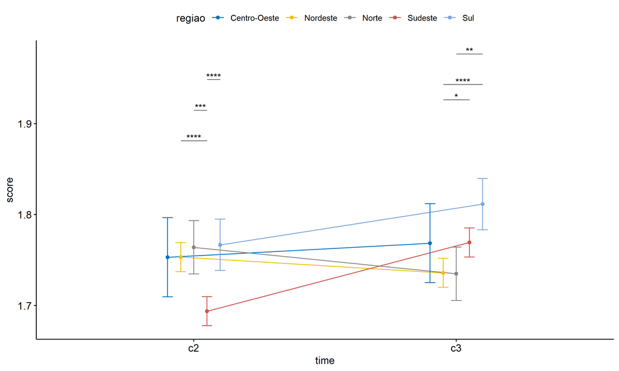

```r
pwc <- add_xy_position(pwc, x = "time", fun = "mean_se", dodge = 0.25)
pd <- position_dodge(width = 0.25)
ggline(emms, x = "time", y = "emmean", color = "regiao",
       palette = c("#0073C2FF","#EFC000FF","#868686FF","#CD534CFF","#7AA6DCFF"),
       position = pd, ylab = "score") +
  geom_errorbar(aes(ymin = conf.low, ymax = conf.high, color = regiao),
                position = pd, width = 0.2) +
  stat_pvalue_manual(pwc, hide.ns = T, tip.length = F, linetype = 1)
```

```r
(pwc <- ldat %>% group_by(regiao) %>%
    emmeans_test(score ~ time, detailed = T, p.adjust.method = "bonferroni"))
```

```
## # A tibble: 5 × 15
##   regiao     term  .y.   group1 group2 null.value estimate     se    df conf.low
## * <fct>      <chr> <chr> <chr>  <chr>       <dbl>    <dbl>  <dbl> <dbl>    <dbl>
## 1 Centro-Oe… time  score c2     c3              0  -0.0154 0.0314  8074 -0.0769
## 2 Nordeste   time  score c2     c3              0   0.0174 0.0115  8074 -0.00524
## 3 Norte      time  score c2     c3              0   0.0291 0.0212  8074 -0.0123
## 4 Sudeste    time  score c2     c3              0  -0.0755 0.0115  8074 -0.0980
## 5 Sul        time  score c2     c3              0  -0.0447 0.0203  8074 -0.0845
## # ℹ 5 more variables: conf.high <dbl>, statistic <dbl>, p <dbl>, p.adj <dbl>,
## #   p.adj.signif <chr>
```

| regiao | term | .y. | group1 | group2 | null.value | estimate | se | df | conf.low | conf.high | statistic | p | p.adj | p.adj.signif |
| --- | --- | --- | --- | --- | --- | --- | --- | --- | --- | --- | --- | --- | --- | --- |
| Centro-Oeste | time | score | c2 | c3 | 0 | -0.015 | 0.031 | 8074 | -0.077 | 0.046 | -0.492 | 0.623 | 0.623 | ns |
| Nordeste | time | score | c2 | c3 | 0 | 0.017 | 0.012 | 8074 | -0.005 | 0.040 | 1.506 | 0.132 | 0.132 | ns |
| Norte | time | score | c2 | c3 | 0 | 0.029 | 0.021 | 8074 | -0.012 | 0.071 | 1.377 | 0.169 | 0.169 | ns |
| Sudeste | time | score | c2 | c3 | 0 | -0.076 | 0.011 | 8074 | -0.098 | -0.053 | -6.569 | 0.000 | 0.000 | **** |
| Sul | time | score | c2 | c3 | 0 | -0.045 | 0.020 | 8074 | -0.085 | -0.005 | -2.203 | 0.028 | 0.028 | * |

```r
(emms <- get_emmeans(pwc))
```

```
## # A tibble: 10 × 8
##    regiao       time  emmean      se    df conf.low conf.high method
##    <fct>        <fct>  <dbl>   <dbl> <dbl>    <dbl>     <dbl> <chr>
##  1 Centro-Oeste c2      1.75 0.0222   8074     1.71      1.80 Emmeans test
##  2 Centro-Oeste c3      1.77 0.0222   8074     1.73      1.81 Emmeans test
##  3 Nordeste     c2      1.75 0.00815  8074     1.74      1.77 Emmeans test
##  4 Nordeste     c3      1.74 0.00815  8074     1.72      1.75 Emmeans test
##  5 Norte        c2      1.76 0.0150   8074     1.73      1.79 Emmeans test
##  6 Norte        c3      1.73 0.0150   8074     1.71      1.76 Emmeans test
##  7 Sudeste      c2      1.69 0.00813  8074     1.68      1.71 Emmeans test
##  8 Sudeste      c3      1.77 0.00813  8074     1.75      1.79 Emmeans test
##  9 Sul          c2      1.77 0.0144   8074     1.74      1.79 Emmeans test
## 10 Sul          c3      1.81 0.0144   8074     1.78      1.84 Emmeans test
```

| regiao | time | emmean | se | df | conf.low | conf.high | method |
| --- | --- | --- | --- | --- | --- | --- | --- |
| Centro-Oeste | c2 | 1.753 | 0.022 | 8074 | 1.710 | 1.797 | Emmeans test |
| Centro-Oeste | c3 | 1.769 | 0.022 | 8074 | 1.725 | 1.812 | Emmeans test |
| Nordeste | c2 | 1.753 | 0.008 | 8074 | 1.737 | 1.769 | Emmeans test |
| Nordeste | c3 | 1.736 | 0.008 | 8074 | 1.720 | 1.752 | Emmeans test |
| Norte | c2 | 1.764 | 0.015 | 8074 | 1.735 | 1.793 | Emmeans test |
| Norte | c3 | 1.735 | 0.015 | 8074 | 1.706 | 1.764 | Emmeans test |
| Sudeste | c2 | 1.694 | 0.008 | 8074 | 1.678 | 1.710 | Emmeans test |
| Sudeste | c3 | 1.769 | 0.008 | 8074 | 1.753 | 1.785 | Emmeans test |
| Sul | c2 | 1.767 | 0.014 | 8074 | 1.739 | 1.795 | Emmeans test |
| Sul | c3 | 1.811 | 0.014 | 8074 | 1.783 | 1.840 | Emmeans test |

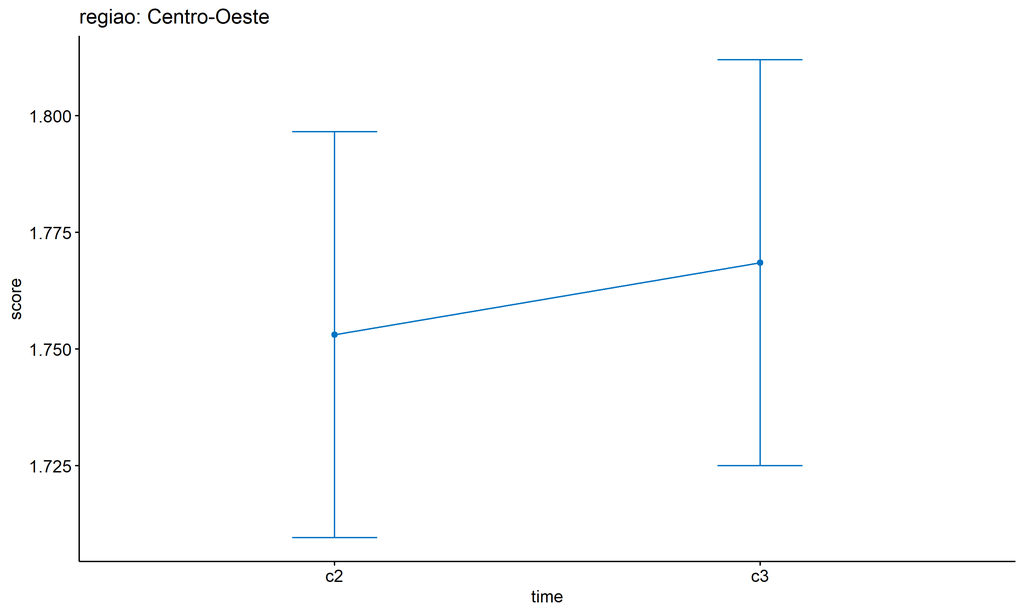

```r
emms.gg <- emms[which(emms$regiao == "Centro-Oeste"),]
if (nrow(emms.gg) > 0)
  ggline(emms.gg, x = "time", y = "emmean", color = "#0073C2FF", ylab = "score") +
    geom_errorbar(aes(ymin = conf.low, ymax = conf.high),
                  width = 0.2, color = "#0073C2FF") +
    stat_pvalue_manual(
      add_xy_position(pwc[which(pwc$regiao == "Centro-Oeste"),],
                      x = "time", fun = "mean_se"),
      hide.ns = T, color = "#0073C2FF", tip.length = F) +
    labs(title = "regiao: Centro-Oeste")+
    theme(legend.text = element_blank())
```

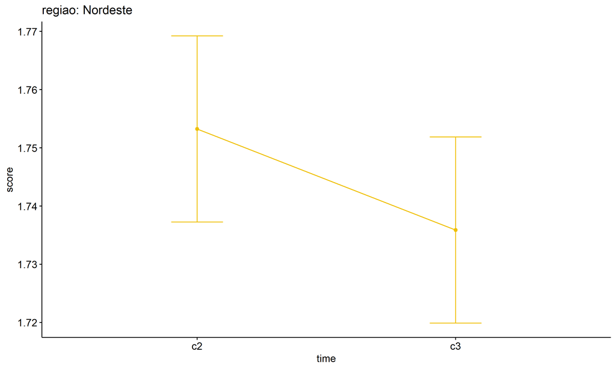

```r
emms.gg <- emms[which(emms$regiao == "Nordeste"),]
if (nrow(emms.gg) > 0)
  ggline(emms.gg, x = "time", y = "emmean", color = "#EFC000FF", ylab = "score") +
    geom_errorbar(aes(ymin = conf.low, ymax = conf.high),
                  width = 0.2, color = "#EFC000FF") +
    stat_pvalue_manual(
      add_xy_position(pwc[which(pwc$regiao == "Nordeste"),],
                      x = "time", fun = "mean_se"),
      hide.ns = T, color = "#EFC000FF", tip.length = F) +
    labs(title = "regiao: Nordeste")+
    theme(legend.text = element_blank())
```

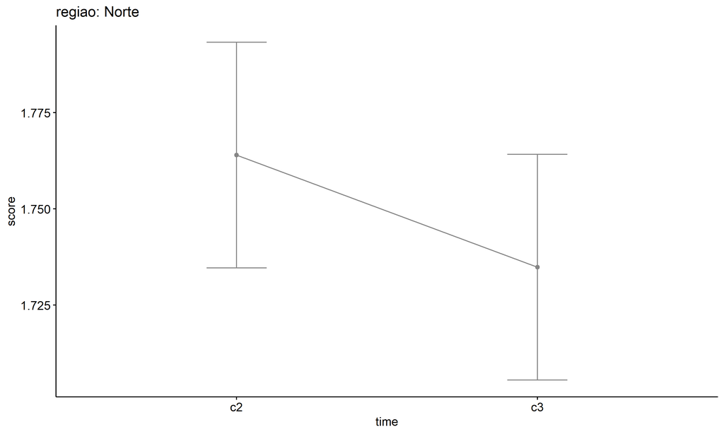

```r
emms.gg <- emms[which(emms$regiao == "Norte"),]
if (nrow(emms.gg) > 0)
  ggline(emms.gg, x = "time", y = "emmean", color = "#868686FF", ylab = "score") +
    geom_errorbar(aes(ymin = conf.low, ymax = conf.high),
                  width = 0.2, color = "#868686FF") +
    stat_pvalue_manual(
      add_xy_position(pwc[which(pwc$regiao == "Norte"),],
                      x = "time", fun = "mean_se"),
      hide.ns = T, color = "#868686FF", tip.length = F) +
    labs(title = "regiao: Norte")+
    theme(legend.text = element_blank())
```

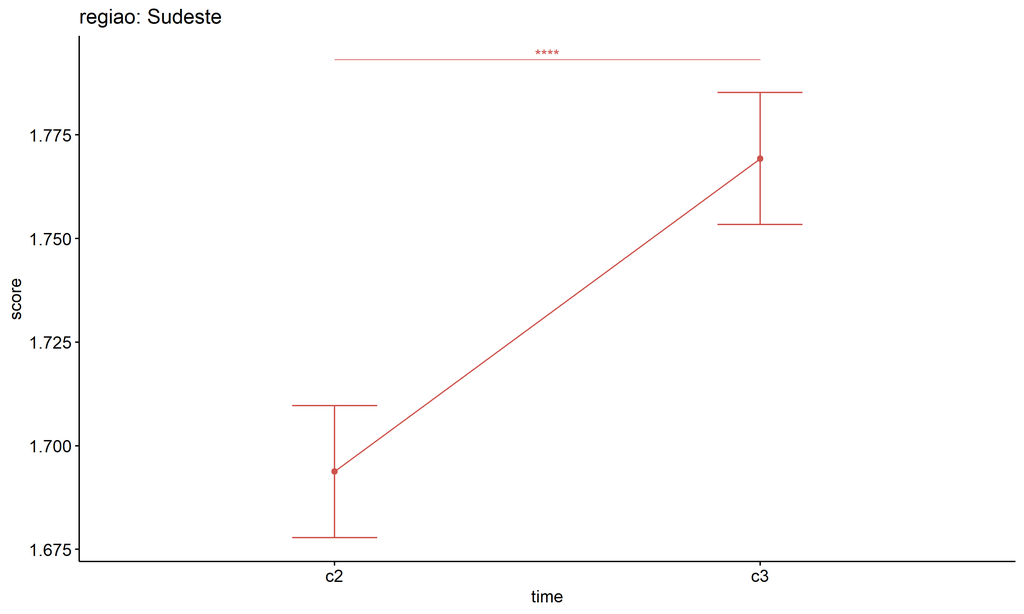

```r
emms.gg <- emms[which(emms$regiao == "Sudeste"),]
if (nrow(emms.gg) > 0)
  ggline(emms.gg, x = "time", y = "emmean", color = "#CD534CFF", ylab = "score") +
    geom_errorbar(aes(ymin = conf.low, ymax = conf.high),
                  width = 0.2, color = "#CD534CFF") +
    stat_pvalue_manual(
      add_xy_position(pwc[which(pwc$regiao == "Sudeste"),],
                      x = "time", fun = "mean_se"),
      hide.ns = T, color = "#CD534CFF", tip.length = F) +
    labs(title = "regiao: Sudeste")+
    theme(legend.text = element_blank())
```

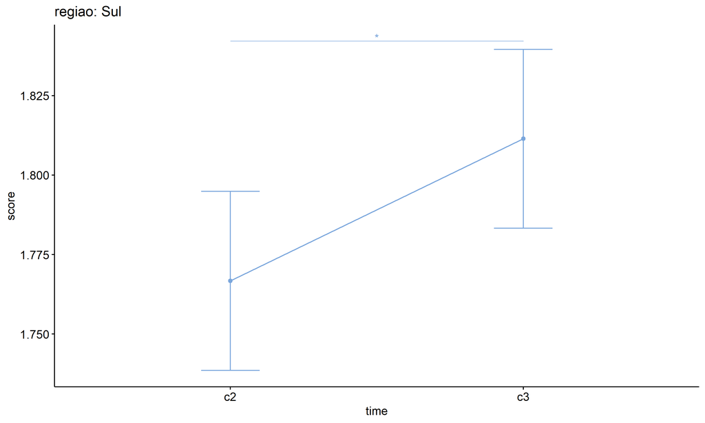

```r
emms.gg <- emms[which(emms$regiao == "Sul"),]
if (nrow(emms.gg) > 0)
  ggline(emms.gg, x = "time", y = "emmean", color = "#7AA6DCFF", ylab = "score") +
    geom_errorbar(aes(ymin = conf.low, ymax = conf.high),
                  width = 0.2, color = "#7AA6DCFF") +
    stat_pvalue_manual(
      add_xy_position(pwc[which(pwc$regiao == "Sul"),],
                      x = "time", fun = "mean_se"),
      hide.ns = T, color = "#7AA6DCFF", tip.length = F) +
    labs(title = "regiao: Sul")+
    theme(legend.text = element_blank())
```

## PairWise Computation after removing non.normal data

```r
if (length(non.ids) > 0)
  (pwc2 <- ldat2 %>% group_by(time) %>%
     emmeans_test(score ~ regiao, detailed = T, p.adjust.method = "bonferroni"))
```

```r
if (length(non.ids) > 0)
  (emms2 <- get_emmeans(pwc2))
```

```r
if (length(non.ids) > 0) {
  pwc2 <- add_xy_position(pwc2, x = "time", fun = "mean_se", dodge = 0.25)
  pd2 <- position_dodge(width = 0.25)

  ggline(emms2, x = "time", y = "emmean", color = "regiao",
         palette = c("#0073C2FF","#EFC000FF","#868686FF","#CD534CFF","#7AA6DCFF"),
         position = pd, ylab = "score") +
    geom_errorbar(aes(ymin = conf.low, ymax = conf.high, color = regiao),
                position = pd, width = 0.2) +
    stat_pvalue_manual(pwc2, hide.ns = T, tip.length = F, linetype = 1)
}
```

```r
if (length(non.ids) > 0)
  (pwc2 <- ldat2 %>% group_by(regiao) %>%
     emmeans_test(score ~ time, detailed = T, p.adjust.method = "bonferroni"))
```

```r
if (length(non.ids) > 0)
  (emms2 <- get_emmeans(pwc2))
```

```r
if (length(non.ids) > 0) {
  emms.gg <- emms2[which(emms2$regiao == "Centro-Oeste"),]
  if (nrow(emms.gg) > 0)
    ggline(emms.gg, x = "time", y = "emmean", color = "#0073C2FF", ylab = "score") +
    geom_errorbar(aes(ymin = conf.low, ymax = conf.high),
                  width = 0.2, color = "#0073C2FF") +
    stat_pvalue_manual(
      add_xy_position(pwc[which(pwc$regiao == "Centro-Oeste"),],
                      x = "time", fun = "mean_se"),
      hide.ns = T, color = "#0073C2FF", tip.length = F) +
    labs(title = "regiao: Centro-Oeste") +
    theme(legend.text = element_blank())
}
```

```r
if (length(non.ids) > 0) {
  emms.gg <- emms2[which(emms2$regiao == "Nordeste"),]
  if (nrow(emms.gg) > 0)
    ggline(emms.gg, x = "time", y = "emmean", color = "#EFC000FF", ylab = "score") +
    geom_errorbar(aes(ymin = conf.low, ymax = conf.high),
                  width = 0.2, color = "#EFC000FF") +
    stat_pvalue_manual(
      add_xy_position(pwc[which(pwc$regiao == "Nordeste"),],
                      x = "time", fun = "mean_se"),
      hide.ns = T, color = "#EFC000FF", tip.length = F) +
    labs(title = "regiao: Nordeste") +
    theme(legend.text = element_blank())
}
```

```r
if (length(non.ids) > 0) {
  emms.gg <- emms2[which(emms2$regiao == "Norte"),]
  if (nrow(emms.gg) > 0)
    ggline(emms.gg, x = "time", y = "emmean", color = "#868686FF", ylab = "score") +
    geom_errorbar(aes(ymin = conf.low, ymax = conf.high),
                  width = 0.2, color = "#868686FF") +
    stat_pvalue_manual(
      add_xy_position(pwc[which(pwc$regiao == "Norte"),],
                      x = "time", fun = "mean_se"),
      hide.ns = T, color = "#868686FF", tip.length = F) +
    labs(title = "regiao: Norte") +
    theme(legend.text = element_blank())
}
```

```r
if (length(non.ids) > 0) {
  emms.gg <- emms2[which(emms2$regiao == "Sudeste"),]
  if (nrow(emms.gg) > 0)
    ggline(emms.gg, x = "time", y = "emmean", color = "#CD534CFF", ylab = "score") +
    geom_errorbar(aes(ymin = conf.low, ymax = conf.high),
                  width = 0.2, color = "#CD534CFF") +
    stat_pvalue_manual(
      add_xy_position(pwc[which(pwc$regiao == "Sudeste"),],
                      x = "time", fun = "mean_se"),
      hide.ns = T, color = "#CD534CFF", tip.length = F) +
    labs(title = "regiao: Sudeste") +
    theme(legend.text = element_blank())
}
```

```r
if (length(non.ids) > 0) {
  emms.gg <- emms2[which(emms2$regiao == "Sul"),]
  if (nrow(emms.gg) > 0)
    ggline(emms.gg, x = "time", y = "emmean", color = "#7AA6DCFF", ylab = "score") +
    geom_errorbar(aes(ymin = conf.low, ymax = conf.high),
                  width = 0.2, color = "#7AA6DCFF") +
    stat_pvalue_manual(
      add_xy_position(pwc[which(pwc$regiao == "Sul"),],
                      x = "time", fun = "mean_se"),
      hide.ns = T, color = "#7AA6DCFF", tip.length = F) +
    labs(title = "regiao: Sul") +
    theme(legend.text = element_blank())
}
```

# ANOVA: score ~ time*porte + Error(id/time)

## Data Preparation

```r
data <- edat[,c("aluno_id","porte","ciclo","score")]
data <- data[data$ciclo %in% c("Segundo Ciclo","Terceiro Ciclo"),]
data$ciclo <- factor(data$ciclo, c("Segundo Ciclo","Terceiro Ciclo"))
data <- unique(data)

wdat <- spread(data, ciclo, score)
wdat <- wdat[complete.cases(wdat),]
colnames(wdat) <- c("id","porte","c2","c3")

ldat <- gather(wdat, key = time, value = score, c2,c3) %>%
  convert_as_factor(id, time)
ldat <- remove_group_data(ldat, "score", c("time", "porte"), n.limit = 30)
ldat$porte <- factor(ldat$porte, sort(unique(ldat$porte)))
```

### Check assumptions: Identifying Outliers

```r
outliers <- identify_outliers(group_by(ldat, time, porte), score)
(outliers <- outliers[outliers$is.extreme == T,])
```

```
## # A tibble: 1 × 6
##   porte                                  time  id    score is.outlier is.extreme
##   <fct>                                  <fct> <fct> <dbl> <lgl>      <lgl>
## 1 Entre 51 e 200 matrículas de escolari… c2    oEDV…     3 TRUE       TRUE
```

| porte | time | id | score | is.outlier | is.extreme |
| --- | --- | --- | --- | --- | --- |
| Entre 51 e 200 matrículas de escolarização | c2 | oEDVJwdVHdc8vvUBo2jy | 3 | TRUE | TRUE |

### Check assumptions: Normality Test

```r
(normality.df <- normality.test.per.groups(ldat, "score", c("time", "porte")))
```

```
##      var variable time                                        porte    n
## 1  score    score   c2           Até 50 matrículas de escolarização   39
## 2  score    score   c2  Entre 201 e 500 matrículas de escolarização 1488
## 3  score    score   c2 Entre 501 e 1000 matrículas de escolarização 1922
## 4  score    score   c2   Entre 51 e 200 matrículas de escolarização  502
## 5  score    score   c2     Mais de 1000 matrículas de escolarização   91
## 6  score    score   c3           Até 50 matrículas de escolarização   39
## 7  score    score   c3  Entre 201 e 500 matrículas de escolarização 1488
## 8  score    score   c3 Entre 501 e 1000 matrículas de escolarização 1922
## 9  score    score   c3   Entre 51 e 200 matrículas de escolarização  502
## 10 score    score   c3     Mais de 1000 matrículas de escolarização   91
##     skewness    kurtosis symmetry   statistic       method            p
## 1  0.7684263  0.04182431       NO   0.8920037 Shapiro-Wilk 1.311859e-03
## 2  0.5948673  0.28416721       NO  80.9912355   D'Agostino 0.000000e+00
## 3  0.6929806  0.60819204       NO 147.0342720   D'Agostino 0.000000e+00
```

[output cut: 18 more lines]

| var | variable | time | porte | n | skewness | kurtosis | symmetry | statistic | method | p | p.signif | normality |
| --- | --- | --- | --- | --- | --- | --- | --- | --- | --- | --- | --- | --- |
| score | score | c2 | Até 50 matrículas de escolarização | 39 | 0.768 | 0.042 | NO | 0.892 | Shapiro-Wilk | 0.001 | ** | NO |
| score | score | c2 | Entre 201 e 500 matrículas de escolarização | 1488 | 0.595 | 0.284 | NO | 80.991 | D’Agostino | 0.000 | **** | - |
| score | score | c2 | Entre 501 e 1000 matrículas de escolarização | 1922 | 0.693 | 0.608 | NO | 147.034 | D’Agostino | 0.000 | **** | - |
| score | score | c2 | Entre 51 e 200 matrículas de escolarização | 502 | 0.504 | 0.119 | NO | 20.250 | D’Agostino | 0.000 | *** | - |
| score | score | c2 | Mais de 1000 matrículas de escolarização | 91 | 0.462 | -0.246 | YES | 3.549 | D’Agostino | 0.170 | ns | YES |
| score | score | c3 | Até 50 matrículas de escolarização | 39 | 0.464 | -0.079 | YES | 0.849 | Shapiro-Wilk | 0.000 | *** | NO |
| score | score | c3 | Entre 201 e 500 matrículas de escolarização | 1488 | 0.648 | 0.201 | NO | 91.262 | D’Agostino | 0.000 | **** | - |
| score | score | c3 | Entre 501 e 1000 matrículas de escolarização | 1922 | 0.635 | 0.059 | NO | 110.853 | D’Agostino | 0.000 | **** | - |
| score | score | c3 | Entre 51 e 200 matrículas de escolarização | 502 | 0.565 | -0.161 | NO | 24.534 | D’Agostino | 0.000 | **** | - |
| score | score | c3 | Mais de 1000 matrículas de escolarização | 91 | 0.489 | -0.180 | YES | 3.935 | D’Agostino | 0.140 | ns | YES |

```r
(non.ids <- unique(do.call(
  c, lapply(which(normality.df$normality == 'NO'), FUN = function(i) {
  idx = which(ldat$time == normality.df$time[i] &
                ldat$porte == normality.df$porte[i])
  getNonNormal(ldat$"score"[idx], ldat$id[idx])
}))))
```

```
##  [1] "JKEvnqvCpv10PSAycuzr" "jmQzNTyBvDUbdvkuw8jn" "xIbOtpjs3DYwYtdjDP3I"
##  [4] "o6lY8TqKQe4iwloQR4xT" "ZLMQovpttvwheGbGVGgD" "ZFu1gNSlJi6WerbxgitV"
##  [7] "NMVbbMCMMnJqu44vX7PD" "x1mc3liCVyASikuju4tm" "tNXwXm3gSuhYYg0Zi6Jt"
## [10] "kEOMbjs2x9ykNUE50l4f" "Q20fwNjCOulqbeL8zxzc" "pURonQfq0IqWOeSSc60L"
## [13] "wEcu8jbom5Ui9WLqplNb" "UPhWAzsPiUaMEPrU6QNA" "pPT18qVe3Dm7qXdm2Hta"
## [16] "PcC5fOMivLm7NNMwQOjR" "OWGqzE4ZtIzhgS8Ih5la" "MqmsPo8CcZiXbjHViNOu"
## [19] "NNoGTAXet281NFr5KivO" "lVkuYCExq2m5gkeiPjq8" "mArPBVXkChx4lhdupeWs"
## [22] "LFpk4mdWuO00RqnVLSXb" "KvCdPigPFrWJKsOUM12q"
```

```r
if (length(non.ids) > 0)
  ldat2 <- ldat[!ldat$id %in% non.ids,]
```

### Summary Statistics

```r
(sdat <- ldat %>% group_by(time, porte) %>%
   get_summary_stats(score, type = "mean_sd"))
```

```
## # A tibble: 10 × 6
##    porte                                        time  variable     n  mean    sd
##    <fct>                                        <fct> <fct>    <dbl> <dbl> <dbl>
##  1 Até 50 matrículas de escolarização           c2    score       39  1.78 0.353
##  2 Entre 201 e 500 matrículas de escolarização  c2    score     1488  1.74 0.303
##  3 Entre 501 e 1000 matrículas de escolarização c2    score     1922  1.72 0.288
##  4 Entre 51 e 200 matrículas de escolarização   c2    score      502  1.77 0.323
##  5 Mais de 1000 matrículas de escolarização     c2    score       91  1.74 0.258
##  6 Até 50 matrículas de escolarização           c3    score       39  1.74 0.244
##  7 Entre 201 e 500 matrículas de escolarização  c3    score     1488  1.75 0.313
##  8 Entre 501 e 1000 matrículas de escolarização c3    score     1922  1.76 0.334
##  9 Entre 51 e 200 matrículas de escolarização   c3    score      502  1.77 0.341
## 10 Mais de 1000 matrículas de escolarização     c3    score       91  1.75 0.342
```

| porte | time | variable | n | mean | sd |
| --- | --- | --- | --- | --- | --- |
| Até 50 matrículas de escolarização | c2 | score | 39 | 1.782 | 0.353 |
| Entre 201 e 500 matrículas de escolarização | c2 | score | 1488 | 1.745 | 0.303 |
| Entre 501 e 1000 matrículas de escolarização | c2 | score | 1922 | 1.715 | 0.288 |
| Entre 51 e 200 matrículas de escolarização | c2 | score | 502 | 1.774 | 0.323 |
| Mais de 1000 matrículas de escolarização | c2 | score | 91 | 1.736 | 0.258 |
| Até 50 matrículas de escolarização | c3 | score | 39 | 1.744 | 0.244 |
| Entre 201 e 500 matrículas de escolarização | c3 | score | 1488 | 1.748 | 0.313 |
| Entre 501 e 1000 matrículas de escolarização | c3 | score | 1922 | 1.764 | 0.334 |
| Entre 51 e 200 matrículas de escolarização | c3 | score | 502 | 1.772 | 0.341 |
| Mais de 1000 matrículas de escolarização | c3 | score | 91 | 1.747 | 0.342 |

```r
if (length(non.ids) > 0)
  (sdat <- ldat2 %>% group_by(time, porte) %>%
      get_summary_stats(score, type = "mean_sd"))
```

```
## # A tibble: 10 × 6
##    porte                                        time  variable     n  mean    sd
##    <fct>                                        <fct> <fct>    <dbl> <dbl> <dbl>
##  1 Até 50 matrículas de escolarização           c2    score       16  1.79 0.301
##  2 Entre 201 e 500 matrículas de escolarização  c2    score     1488  1.74 0.303
##  3 Entre 501 e 1000 matrículas de escolarização c2    score     1922  1.72 0.288
##  4 Entre 51 e 200 matrículas de escolarização   c2    score      502  1.77 0.323
##  5 Mais de 1000 matrículas de escolarização     c2    score       91  1.74 0.258
##  6 Até 50 matrículas de escolarização           c3    score       16  1.83 0.292
##  7 Entre 201 e 500 matrículas de escolarização  c3    score     1488  1.75 0.313
##  8 Entre 501 e 1000 matrículas de escolarização c3    score     1922  1.76 0.334
##  9 Entre 51 e 200 matrículas de escolarização   c3    score      502  1.77 0.341
## 10 Mais de 1000 matrículas de escolarização     c3    score       91  1.75 0.342
```

| porte | time | variable | n | mean | sd |
| --- | --- | --- | --- | --- | --- |
| Até 50 matrículas de escolarização | c2 | score | 16 | 1.792 | 0.301 |
| Entre 201 e 500 matrículas de escolarização | c2 | score | 1488 | 1.745 | 0.303 |
| Entre 501 e 1000 matrículas de escolarização | c2 | score | 1922 | 1.715 | 0.288 |
| Entre 51 e 200 matrículas de escolarização | c2 | score | 502 | 1.774 | 0.323 |
| Mais de 1000 matrículas de escolarização | c2 | score | 91 | 1.736 | 0.258 |
| Até 50 matrículas de escolarização | c3 | score | 16 | 1.833 | 0.292 |
| Entre 201 e 500 matrículas de escolarização | c3 | score | 1488 | 1.748 | 0.313 |
| Entre 501 e 1000 matrículas de escolarização | c3 | score | 1922 | 1.764 | 0.334 |
| Entre 51 e 200 matrículas de escolarização | c3 | score | 502 | 1.772 | 0.341 |
| Mais de 1000 matrículas de escolarização | c3 | score | 91 | 1.747 | 0.342 |

## ANOVA Computation

```r
(res.aov <- anova_test(ldat, dv = score, wid = id, between = porte, within = time))
```

```
## ANOVA Table (type III tests)
##
##       Effect DFn  DFd     F     p p<.05      ges
## 1      porte   4 4037 2.054 0.084       1.00e-03
## 2       time   1 4037 0.073 0.787       7.69e-06
## 3 porte:time   4 4037 3.674 0.005     * 2.00e-03
```

## ANOVA Computation after removing non.normal data

```r
if (length(non.ids) > 0)
  (res.aov2 <- anova_test(ldat2, dv = score, wid = id, between = porte , within = time))
```

```
## ANOVA Table (type III tests)
##
##       Effect DFn  DFd     F     p p<.05      ges
## 1      porte   4 4014 2.319 0.055       1.00e-03
## 2       time   1 4014 0.815 0.367       8.66e-05
## 3 porte:time   4 4014 3.449 0.008     * 1.00e-03
```

## PairWise Computation

```r
(pwc <- ldat %>% group_by(time) %>%
   emmeans_test(score ~ porte, detailed = T, p.adjust.method = "bonferroni"))
```

```
## # A tibble: 20 × 15
##    time  term  .y.   group1     group2 null.value estimate     se    df conf.low
##  * <fct> <chr> <chr> <chr>      <chr>       <dbl>    <dbl>  <dbl> <dbl>    <dbl>
##  1 c2    porte score Até 50 ma… Entre…          0  3.72e-2 0.0507  8074 -0.0622
##  2 c2    porte score Até 50 ma… Entre…          0  6.74e-2 0.0506  8074 -0.0318
##  3 c2    porte score Até 50 ma… Entre…          0  7.70e-3 0.0520  8074 -0.0942
##  4 c2    porte score Até 50 ma… Mais …          0  4.58e-2 0.0599  8074 -0.0716
##  5 c2    porte score Entre 201… Entre…          0  3.02e-2 0.0108  8074  0.00901
##  6 c2    porte score Entre 201… Entre…          0 -2.95e-2 0.0161  8074 -0.0612
##  7 c2    porte score Entre 201… Mais …          0  8.55e-3 0.0338  8074 -0.0577
##  8 c2    porte score Entre 501… Entre…          0 -5.97e-2 0.0157  8074 -0.0905
##  9 c2    porte score Entre 501… Mais …          0 -2.16e-2 0.0336  8074 -0.0874
## 10 c2    porte score Entre 51 … Mais …          0  3.81e-2 0.0356  8074 -0.0318
## 11 c3    porte score Até 50 ma… Entre…          0 -3.95e-3 0.0507  8074 -0.103
## 12 c3    porte score Até 50 ma… Entre…          0 -2.05e-2 0.0506  8074 -0.120
## 13 c3    porte score Até 50 ma… Entre…          0 -2.80e-2 0.0520  8074 -0.130
## 14 c3    porte score Até 50 ma… Mais …          0 -3.66e-3 0.0599  8074 -0.121
## 15 c3    porte score Entre 201… Entre…          0 -1.66e-2 0.0108  8074 -0.0378
## 16 c3    porte score Entre 201… Entre…          0 -2.40e-2 0.0161  8074 -0.0557
## 17 c3    porte score Entre 201… Mais …          0  2.83e-4 0.0338  8074 -0.0659
## 18 c3    porte score Entre 501… Entre…          0 -7.45e-3 0.0157  8074 -0.0382
## 19 c3    porte score Entre 501… Mais …          0  1.69e-2 0.0336  8074 -0.0489
## 20 c3    porte score Entre 51 … Mais …          0  2.43e-2 0.0356  8074 -0.0455
## # ℹ 5 more variables: conf.high <dbl>, statistic <dbl>, p <dbl>, p.adj <dbl>,
## #   p.adj.signif <chr>
```

| time | term | .y. | group1 | group2 | null.value | estimate | se | df | conf.low | conf.high | statistic | p | p.adj | p.adj.signif |
| --- | --- | --- | --- | --- | --- | --- | --- | --- | --- | --- | --- | --- | --- | --- |
| c2 | porte | score | Até 50 matrículas de escolarização | Entre 201 e 500 matrículas de escolarização | 0 | 0.037 | 0.051 | 8074 | -0.062 | 0.137 | 0.734 | 0.463 | 1.000 | ns |
| c2 | porte | score | Até 50 matrículas de escolarização | Entre 501 e 1000 matrículas de escolarização | 0 | 0.067 | 0.051 | 8074 | -0.032 | 0.167 | 1.333 | 0.183 | 1.000 | ns |
| c2 | porte | score | Até 50 matrículas de escolarização | Entre 51 e 200 matrículas de escolarização | 0 | 0.008 | 0.052 | 8074 | -0.094 | 0.110 | 0.148 | 0.882 | 1.000 | ns |
| c2 | porte | score | Até 50 matrículas de escolarização | Mais de 1000 matrículas de escolarização | 0 | 0.046 | 0.060 | 8074 | -0.072 | 0.163 | 0.765 | 0.444 | 1.000 | ns |
| c2 | porte | score | Entre 201 e 500 matrículas de escolarização | Entre 501 e 1000 matrículas de escolarização | 0 | 0.030 | 0.011 | 8074 | 0.009 | 0.051 | 2.794 | 0.005 | 0.052 | ns |
| c2 | porte | score | Entre 201 e 500 matrículas de escolarização | Entre 51 e 200 matrículas de escolarização | 0 | -0.030 | 0.016 | 8074 | -0.061 | 0.002 | -1.829 | 0.067 | 0.674 | ns |
| c2 | porte | score | Entre 201 e 500 matrículas de escolarização | Mais de 1000 matrículas de escolarização | 0 | 0.009 | 0.034 | 8074 | -0.058 | 0.075 | 0.253 | 0.800 | 1.000 | ns |
| c2 | porte | score | Entre 501 e 1000 matrículas de escolarização | Entre 51 e 200 matrículas de escolarização | 0 | -0.060 | 0.016 | 8074 | -0.090 | -0.029 | -3.809 | 0.000 | 0.001 | ** |
| c2 | porte | score | Entre 501 e 1000 matrículas de escolarização | Mais de 1000 matrículas de escolarização | 0 | -0.022 | 0.034 | 8074 | -0.087 | 0.044 | -0.645 | 0.519 | 1.000 | ns |
| c2 | porte | score | Entre 51 e 200 matrículas de escolarização | Mais de 1000 matrículas de escolarização | 0 | 0.038 | 0.036 | 8074 | -0.032 | 0.108 | 1.069 | 0.285 | 1.000 | ns |
| c3 | porte | score | Até 50 matrículas de escolarização | Entre 201 e 500 matrículas de escolarização | 0 | -0.004 | 0.051 | 8074 | -0.103 | 0.096 | -0.078 | 0.938 | 1.000 | ns |
| c3 | porte | score | Até 50 matrículas de escolarização | Entre 501 e 1000 matrículas de escolarização | 0 | -0.021 | 0.051 | 8074 | -0.120 | 0.079 | -0.406 | 0.685 | 1.000 | ns |
| c3 | porte | score | Até 50 matrículas de escolarização | Entre 51 e 200 matrículas de escolarização | 0 | -0.028 | 0.052 | 8074 | -0.130 | 0.074 | -0.538 | 0.590 | 1.000 | ns |
| c3 | porte | score | Até 50 matrículas de escolarização | Mais de 1000 matrículas de escolarização | 0 | -0.004 | 0.060 | 8074 | -0.121 | 0.114 | -0.061 | 0.951 | 1.000 | ns |
| c3 | porte | score | Entre 201 e 500 matrículas de escolarização | Entre 501 e 1000 matrículas de escolarização | 0 | -0.017 | 0.011 | 8074 | -0.038 | 0.005 | -1.537 | 0.124 | 1.000 | ns |
| c3 | porte | score | Entre 201 e 500 matrículas de escolarização | Entre 51 e 200 matrículas de escolarização | 0 | -0.024 | 0.016 | 8074 | -0.056 | 0.008 | -1.489 | 0.136 | 1.000 | ns |
| c3 | porte | score | Entre 201 e 500 matrículas de escolarização | Mais de 1000 matrículas de escolarização | 0 | 0.000 | 0.034 | 8074 | -0.066 | 0.066 | 0.008 | 0.993 | 1.000 | ns |
| c3 | porte | score | Entre 501 e 1000 matrículas de escolarização | Entre 51 e 200 matrículas de escolarização | 0 | -0.007 | 0.016 | 8074 | -0.038 | 0.023 | -0.475 | 0.635 | 1.000 | ns |
| c3 | porte | score | Entre 501 e 1000 matrículas de escolarização | Mais de 1000 matrículas de escolarização | 0 | 0.017 | 0.034 | 8074 | -0.049 | 0.083 | 0.503 | 0.615 | 1.000 | ns |
| c3 | porte | score | Entre 51 e 200 matrículas de escolarização | Mais de 1000 matrículas de escolarização | 0 | 0.024 | 0.036 | 8074 | -0.046 | 0.094 | 0.683 | 0.495 | 1.000 | ns |

```r
(emms <- get_emmeans(pwc))
```

```
## # A tibble: 10 × 8
##    time  porte                    emmean      se    df conf.low conf.high method
##    <fct> <fct>                     <dbl>   <dbl> <dbl>    <dbl>     <dbl> <chr>
##  1 c2    Até 50 matrículas de es…   1.78 0.0501   8074     1.68      1.88 Emmea…
##  2 c2    Entre 201 e 500 matrícu…   1.74 0.00811  8074     1.73      1.76 Emmea…
##  3 c2    Entre 501 e 1000 matríc…   1.71 0.00713  8074     1.70      1.73 Emmea…
##  4 c2    Entre 51 e 200 matrícul…   1.77 0.0140   8074     1.75      1.80 Emmea…
##  5 c2    Mais de 1000 matrículas…   1.74 0.0328   8074     1.67      1.80 Emmea…
##  6 c3    Até 50 matrículas de es…   1.74 0.0501   8074     1.65      1.84 Emmea…
##  7 c3    Entre 201 e 500 matrícu…   1.75 0.00811  8074     1.73      1.76 Emmea…
##  8 c3    Entre 501 e 1000 matríc…   1.76 0.00713  8074     1.75      1.78 Emmea…
##  9 c3    Entre 51 e 200 matrícul…   1.77 0.0140   8074     1.74      1.80 Emmea…
## 10 c3    Mais de 1000 matrículas…   1.75 0.0328   8074     1.68      1.81 Emmea…
```

| time | porte | emmean | se | df | conf.low | conf.high | method |
| --- | --- | --- | --- | --- | --- | --- | --- |
| c2 | Até 50 matrículas de escolarização | 1.782 | 0.050 | 8074 | 1.684 | 1.880 | Emmeans test |
| c2 | Entre 201 e 500 matrículas de escolarização | 1.745 | 0.008 | 8074 | 1.729 | 1.761 | Emmeans test |
| c2 | Entre 501 e 1000 matrículas de escolarização | 1.715 | 0.007 | 8074 | 1.701 | 1.729 | Emmeans test |
| c2 | Entre 51 e 200 matrículas de escolarização | 1.774 | 0.014 | 8074 | 1.747 | 1.802 | Emmeans test |
| c2 | Mais de 1000 matrículas de escolarização | 1.736 | 0.033 | 8074 | 1.672 | 1.801 | Emmeans test |
| c3 | Até 50 matrículas de escolarização | 1.744 | 0.050 | 8074 | 1.645 | 1.842 | Emmeans test |
| c3 | Entre 201 e 500 matrículas de escolarização | 1.748 | 0.008 | 8074 | 1.732 | 1.763 | Emmeans test |
| c3 | Entre 501 e 1000 matrículas de escolarização | 1.764 | 0.007 | 8074 | 1.750 | 1.778 | Emmeans test |
| c3 | Entre 51 e 200 matrículas de escolarização | 1.772 | 0.014 | 8074 | 1.744 | 1.799 | Emmeans test |
| c3 | Mais de 1000 matrículas de escolarização | 1.747 | 0.033 | 8074 | 1.683 | 1.812 | Emmeans test |

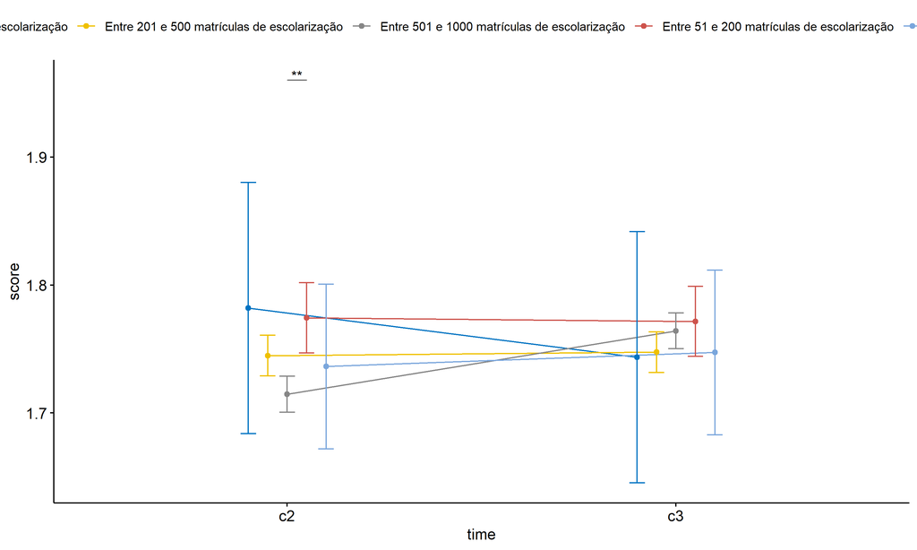

```r
pwc <- add_xy_position(pwc, x = "time", fun = "mean_se", dodge = 0.25)
pd <- position_dodge(width = 0.25)
ggline(emms, x = "time", y = "emmean", color = "porte",
       palette = c("#0073C2FF","#EFC000FF","#868686FF","#CD534CFF","#7AA6DCFF"),
       position = pd, ylab = "score") +
  geom_errorbar(aes(ymin = conf.low, ymax = conf.high, color = porte),
                position = pd, width = 0.2) +
  stat_pvalue_manual(pwc, hide.ns = T, tip.length = F, linetype = 1)
```

```r
(pwc <- ldat %>% group_by(porte) %>%
    emmeans_test(score ~ time, detailed = T, p.adjust.method = "bonferroni"))
```

```
## # A tibble: 5 × 15
##   porte      term  .y.   group1 group2 null.value estimate     se    df conf.low
## * <fct>      <chr> <chr> <chr>  <chr>       <dbl>    <dbl>  <dbl> <dbl>    <dbl>
## 1 Até 50 ma… time  score c2     c3              0  0.0385  0.0708  8074  -0.100
## 2 Entre 201… time  score c2     c3              0 -0.00273 0.0115  8074  -0.0252
## 3 Entre 501… time  score c2     c3              0 -0.0495  0.0101  8074  -0.0693
## 4 Entre 51 … time  score c2     c3              0  0.00277 0.0197  8074  -0.0359
## 5 Mais de 1… time  score c2     c3              0 -0.0110  0.0464  8074  -0.102
## # ℹ 5 more variables: conf.high <dbl>, statistic <dbl>, p <dbl>, p.adj <dbl>,
## #   p.adj.signif <chr>
```

| porte | term | .y. | group1 | group2 | null.value | estimate | se | df | conf.low | conf.high | statistic | p | p.adj | p.adj.signif |
| --- | --- | --- | --- | --- | --- | --- | --- | --- | --- | --- | --- | --- | --- | --- |
| Até 50 matrículas de escolarização | time | score | c2 | c3 | 0 | 0.038 | 0.071 | 8074 | -0.100 | 0.177 | 0.543 | 0.587 | 0.587 | ns |
| Entre 201 e 500 matrículas de escolarização | time | score | c2 | c3 | 0 | -0.003 | 0.011 | 8074 | -0.025 | 0.020 | -0.238 | 0.812 | 0.812 | ns |
| Entre 501 e 1000 matrículas de escolarização | time | score | c2 | c3 | 0 | -0.050 | 0.010 | 8074 | -0.069 | -0.030 | -4.906 | 0.000 | 0.000 | **** |
| Entre 51 e 200 matrículas de escolarização | time | score | c2 | c3 | 0 | 0.003 | 0.020 | 8074 | -0.036 | 0.041 | 0.140 | 0.889 | 0.889 | ns |
| Mais de 1000 matrículas de escolarização | time | score | c2 | c3 | 0 | -0.011 | 0.046 | 8074 | -0.102 | 0.080 | -0.237 | 0.813 | 0.813 | ns |

```r
(emms <- get_emmeans(pwc))
```

```
## # A tibble: 10 × 8
##    porte                    time  emmean      se    df conf.low conf.high method
##    <fct>                    <fct>  <dbl>   <dbl> <dbl>    <dbl>     <dbl> <chr>
##  1 Até 50 matrículas de es… c2      1.78 0.0501   8074     1.68      1.88 Emmea…
##  2 Até 50 matrículas de es… c3      1.74 0.0501   8074     1.65      1.84 Emmea…
##  3 Entre 201 e 500 matrícu… c2      1.74 0.00811  8074     1.73      1.76 Emmea…
##  4 Entre 201 e 500 matrícu… c3      1.75 0.00811  8074     1.73      1.76 Emmea…
##  5 Entre 501 e 1000 matríc… c2      1.71 0.00713  8074     1.70      1.73 Emmea…
##  6 Entre 501 e 1000 matríc… c3      1.76 0.00713  8074     1.75      1.78 Emmea…
##  7 Entre 51 e 200 matrícul… c2      1.77 0.0140   8074     1.75      1.80 Emmea…
##  8 Entre 51 e 200 matrícul… c3      1.77 0.0140   8074     1.74      1.80 Emmea…
##  9 Mais de 1000 matrículas… c2      1.74 0.0328   8074     1.67      1.80 Emmea…
## 10 Mais de 1000 matrículas… c3      1.75 0.0328   8074     1.68      1.81 Emmea…
```

| porte | time | emmean | se | df | conf.low | conf.high | method |
| --- | --- | --- | --- | --- | --- | --- | --- |
| Até 50 matrículas de escolarização | c2 | 1.782 | 0.050 | 8074 | 1.684 | 1.880 | Emmeans test |
| Até 50 matrículas de escolarização | c3 | 1.744 | 0.050 | 8074 | 1.645 | 1.842 | Emmeans test |
| Entre 201 e 500 matrículas de escolarização | c2 | 1.745 | 0.008 | 8074 | 1.729 | 1.761 | Emmeans test |
| Entre 201 e 500 matrículas de escolarização | c3 | 1.748 | 0.008 | 8074 | 1.732 | 1.763 | Emmeans test |
| Entre 501 e 1000 matrículas de escolarização | c2 | 1.715 | 0.007 | 8074 | 1.701 | 1.729 | Emmeans test |
| Entre 501 e 1000 matrículas de escolarização | c3 | 1.764 | 0.007 | 8074 | 1.750 | 1.778 | Emmeans test |
| Entre 51 e 200 matrículas de escolarização | c2 | 1.774 | 0.014 | 8074 | 1.747 | 1.802 | Emmeans test |
| Entre 51 e 200 matrículas de escolarização | c3 | 1.772 | 0.014 | 8074 | 1.744 | 1.799 | Emmeans test |
| Mais de 1000 matrículas de escolarização | c2 | 1.736 | 0.033 | 8074 | 1.672 | 1.801 | Emmeans test |
| Mais de 1000 matrículas de escolarização | c3 | 1.747 | 0.033 | 8074 | 1.683 | 1.812 | Emmeans test |

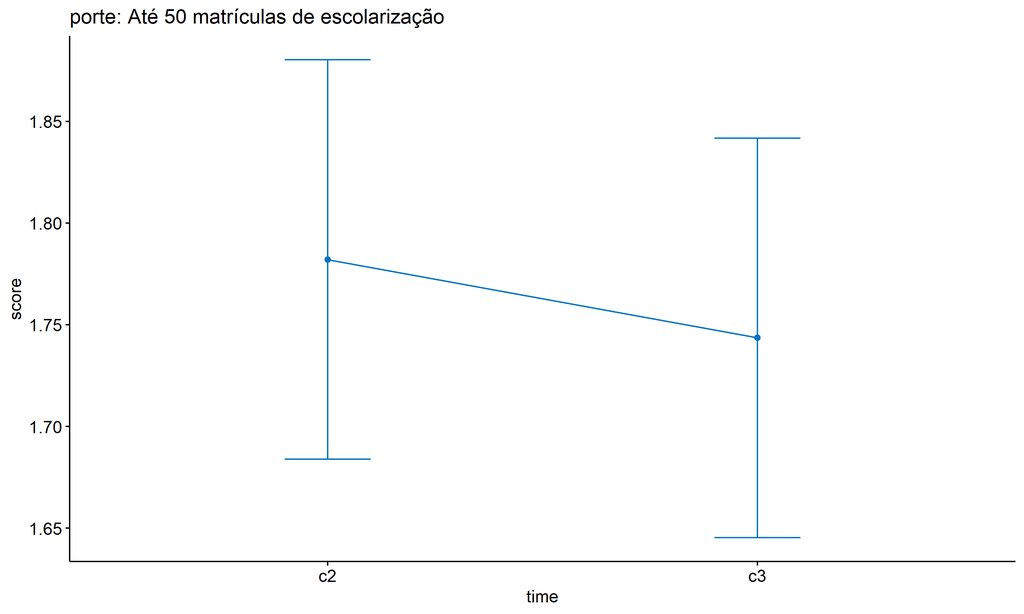

```r
emms.gg <- emms[which(emms$porte == "Até 50 matrículas de escolarização"),]
if (nrow(emms.gg) > 0)
  ggline(emms.gg, x = "time", y = "emmean", color = "#0073C2FF", ylab = "score") +
    geom_errorbar(aes(ymin = conf.low, ymax = conf.high),
                  width = 0.2, color = "#0073C2FF") +
    stat_pvalue_manual(
      add_xy_position(pwc[which(pwc$porte == "Até 50 matrículas de escolarização"),],
                      x = "time", fun = "mean_se"),
      hide.ns = T, color = "#0073C2FF", tip.length = F) +
    labs(title = "porte: Até 50 matrículas de escolarização")+
    theme(legend.text = element_blank())
```

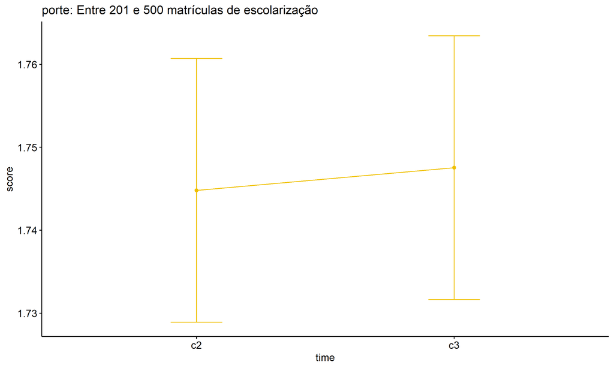

```r
emms.gg <- emms[which(emms$porte == "Entre 201 e 500 matrículas de escolarização"),]
if (nrow(emms.gg) > 0)
  ggline(emms.gg, x = "time", y = "emmean", color = "#EFC000FF", ylab = "score") +
    geom_errorbar(aes(ymin = conf.low, ymax = conf.high),
                  width = 0.2, color = "#EFC000FF") +
    stat_pvalue_manual(
      add_xy_position(pwc[which(pwc$porte == "Entre 201 e 500 matrículas de escolarização"),],
                      x = "time", fun = "mean_se"),
      hide.ns = T, color = "#EFC000FF", tip.length = F) +
    labs(title = "porte: Entre 201 e 500 matrículas de escolarização")+
    theme(legend.text = element_blank())
```

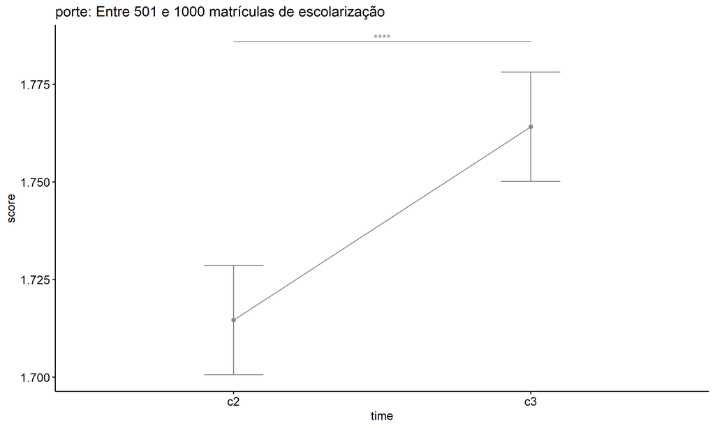

```r
emms.gg <- emms[which(emms$porte == "Entre 501 e 1000 matrículas de escolarização"),]
if (nrow(emms.gg) > 0)
  ggline(emms.gg, x = "time", y = "emmean", color = "#868686FF", ylab = "score") +
    geom_errorbar(aes(ymin = conf.low, ymax = conf.high),
                  width = 0.2, color = "#868686FF") +
    stat_pvalue_manual(
      add_xy_position(pwc[which(pwc$porte == "Entre 501 e 1000 matrículas de escolarização"),],
                      x = "time", fun = "mean_se"),
      hide.ns = T, color = "#868686FF", tip.length = F) +
    labs(title = "porte: Entre 501 e 1000 matrículas de escolarização")+
    theme(legend.text = element_blank())
```

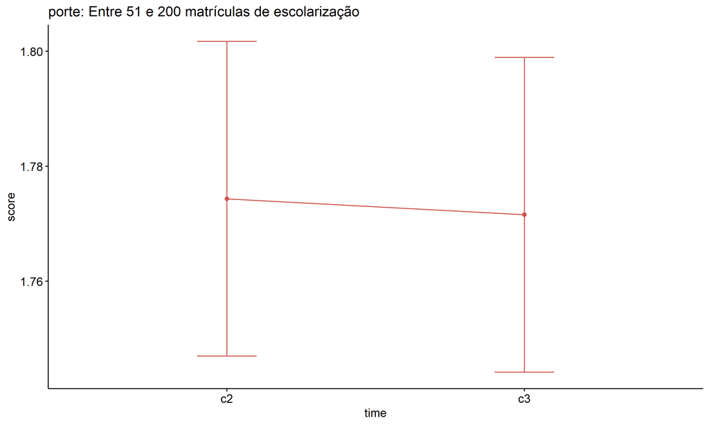

```r
emms.gg <- emms[which(emms$porte == "Entre 51 e 200 matrículas de escolarização"),]
if (nrow(emms.gg) > 0)
  ggline(emms.gg, x = "time", y = "emmean", color = "#CD534CFF", ylab = "score") +
    geom_errorbar(aes(ymin = conf.low, ymax = conf.high),
                  width = 0.2, color = "#CD534CFF") +
    stat_pvalue_manual(
      add_xy_position(pwc[which(pwc$porte == "Entre 51 e 200 matrículas de escolarização"),],
                      x = "time", fun = "mean_se"),
      hide.ns = T, color = "#CD534CFF", tip.length = F) +
    labs(title = "porte: Entre 51 e 200 matrículas de escolarização")+
    theme(legend.text = element_blank())
```

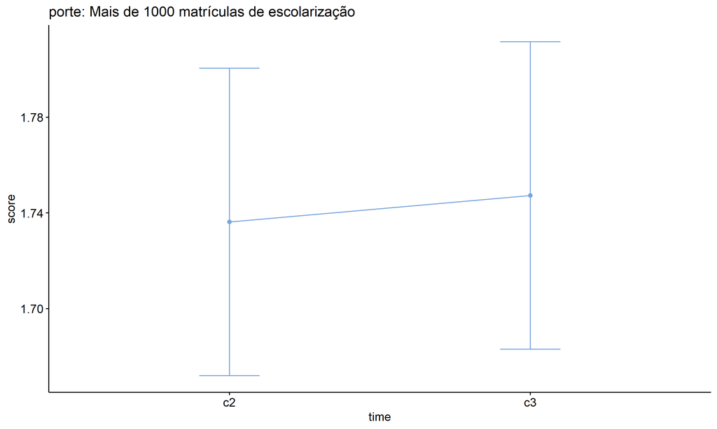

```r
emms.gg <- emms[which(emms$porte == "Mais de 1000 matrículas de escolarização"),]
if (nrow(emms.gg) > 0)
  ggline(emms.gg, x = "time", y = "emmean", color = "#7AA6DCFF", ylab = "score") +
    geom_errorbar(aes(ymin = conf.low, ymax = conf.high),
                  width = 0.2, color = "#7AA6DCFF") +
    stat_pvalue_manual(
      add_xy_position(pwc[which(pwc$porte == "Mais de 1000 matrículas de escolarização"),],
                      x = "time", fun = "mean_se"),
      hide.ns = T, color = "#7AA6DCFF", tip.length = F) +
    labs(title = "porte: Mais de 1000 matrículas de escolarização")+
    theme(legend.text = element_blank())
```

## PairWise Computation after removing non.normal data

```r
if (length(non.ids) > 0)
  (pwc2 <- ldat2 %>% group_by(time) %>%
     emmeans_test(score ~ porte, detailed = T, p.adjust.method = "bonferroni"))
```

```
## # A tibble: 20 × 15
##    time  term  .y.   group1     group2 null.value estimate     se    df conf.low
##  * <fct> <chr> <chr> <chr>      <chr>       <dbl>    <dbl>  <dbl> <dbl>    <dbl>
##  1 c2    porte score Até 50 ma… Entre…          0  4.69e-2 0.0786  8028 -0.107
##  2 c2    porte score Até 50 ma… Entre…          0  7.70e-2 0.0785  8028 -0.0769
##  3 c2    porte score Até 50 ma… Entre…          0  1.73e-2 0.0794  8028 -0.138
##  4 c2    porte score Até 50 ma… Mais …          0  5.54e-2 0.0848  8028 -0.111
##  5 c2    porte score Entre 201… Entre…          0  3.02e-2 0.0108  8028  0.00901
##  6 c2    porte score Entre 201… Entre…          0 -2.95e-2 0.0161  8028 -0.0612
##  7 c2    porte score Entre 201… Mais …          0  8.55e-3 0.0338  8028 -0.0577
##  8 c2    porte score Entre 501… Entre…          0 -5.97e-2 0.0157  8028 -0.0905
##  9 c2    porte score Entre 501… Mais …          0 -2.16e-2 0.0336  8028 -0.0874
## 10 c2    porte score Entre 51 … Mais …          0  3.81e-2 0.0356  8028 -0.0318
## 11 c3    porte score Até 50 ma… Entre…          0  8.58e-2 0.0786  8028 -0.0683
## 12 c3    porte score Até 50 ma… Entre…          0  6.92e-2 0.0785  8028 -0.0847
## 13 c3    porte score Até 50 ma… Entre…          0  6.18e-2 0.0794  8028 -0.0940
## 14 c3    porte score Até 50 ma… Mais …          0  8.61e-2 0.0848  8028 -0.0802
## 15 c3    porte score Entre 201… Entre…          0 -1.66e-2 0.0108  8028 -0.0378
## 16 c3    porte score Entre 201… Entre…          0 -2.40e-2 0.0161  8028 -0.0557
## 17 c3    porte score Entre 201… Mais …          0  2.83e-4 0.0338  8028 -0.0659
## 18 c3    porte score Entre 501… Entre…          0 -7.45e-3 0.0157  8028 -0.0382
## 19 c3    porte score Entre 501… Mais …          0  1.69e-2 0.0336  8028 -0.0489
## 20 c3    porte score Entre 51 … Mais …          0  2.43e-2 0.0356  8028 -0.0455
## # ℹ 5 more variables: conf.high <dbl>, statistic <dbl>, p <dbl>, p.adj <dbl>,
## #   p.adj.signif <chr>
```

| time | term | .y. | group1 | group2 | null.value | estimate | se | df | conf.low | conf.high | statistic | p | p.adj | p.adj.signif |
| --- | --- | --- | --- | --- | --- | --- | --- | --- | --- | --- | --- | --- | --- | --- |
| c2 | porte | score | Até 50 matrículas de escolarização | Entre 201 e 500 matrículas de escolarização | 0 | 0.047 | 0.079 | 8028 | -0.107 | 0.201 | 0.596 | 0.551 | 1.000 | ns |
| c2 | porte | score | Até 50 matrículas de escolarização | Entre 501 e 1000 matrículas de escolarização | 0 | 0.077 | 0.079 | 8028 | -0.077 | 0.231 | 0.981 | 0.327 | 1.000 | ns |
| c2 | porte | score | Até 50 matrículas de escolarização | Entre 51 e 200 matrículas de escolarização | 0 | 0.017 | 0.079 | 8028 | -0.138 | 0.173 | 0.218 | 0.827 | 1.000 | ns |
| c2 | porte | score | Até 50 matrículas de escolarização | Mais de 1000 matrículas de escolarização | 0 | 0.055 | 0.085 | 8028 | -0.111 | 0.222 | 0.653 | 0.514 | 1.000 | ns |
| c2 | porte | score | Entre 201 e 500 matrículas de escolarização | Entre 501 e 1000 matrículas de escolarização | 0 | 0.030 | 0.011 | 8028 | 0.009 | 0.051 | 2.794 | 0.005 | 0.052 | ns |
| c2 | porte | score | Entre 201 e 500 matrículas de escolarização | Entre 51 e 200 matrículas de escolarização | 0 | -0.030 | 0.016 | 8028 | -0.061 | 0.002 | -1.829 | 0.067 | 0.674 | ns |
| c2 | porte | score | Entre 201 e 500 matrículas de escolarização | Mais de 1000 matrículas de escolarização | 0 | 0.009 | 0.034 | 8028 | -0.058 | 0.075 | 0.253 | 0.800 | 1.000 | ns |
| c2 | porte | score | Entre 501 e 1000 matrículas de escolarização | Entre 51 e 200 matrículas de escolarização | 0 | -0.060 | 0.016 | 8028 | -0.090 | -0.029 | -3.809 | 0.000 | 0.001 | ** |
| c2 | porte | score | Entre 501 e 1000 matrículas de escolarização | Mais de 1000 matrículas de escolarização | 0 | -0.022 | 0.034 | 8028 | -0.087 | 0.044 | -0.645 | 0.519 | 1.000 | ns |
| c2 | porte | score | Entre 51 e 200 matrículas de escolarização | Mais de 1000 matrículas de escolarização | 0 | 0.038 | 0.036 | 8028 | -0.032 | 0.108 | 1.069 | 0.285 | 1.000 | ns |
| c3 | porte | score | Até 50 matrículas de escolarização | Entre 201 e 500 matrículas de escolarização | 0 | 0.086 | 0.079 | 8028 | -0.068 | 0.240 | 1.091 | 0.275 | 1.000 | ns |
| c3 | porte | score | Até 50 matrículas de escolarização | Entre 501 e 1000 matrículas de escolarização | 0 | 0.069 | 0.079 | 8028 | -0.085 | 0.223 | 0.881 | 0.378 | 1.000 | ns |
| c3 | porte | score | Até 50 matrículas de escolarização | Entre 51 e 200 matrículas de escolarização | 0 | 0.062 | 0.079 | 8028 | -0.094 | 0.217 | 0.777 | 0.437 | 1.000 | ns |
| c3 | porte | score | Até 50 matrículas de escolarização | Mais de 1000 matrículas de escolarização | 0 | 0.086 | 0.085 | 8028 | -0.080 | 0.252 | 1.015 | 0.310 | 1.000 | ns |
| c3 | porte | score | Entre 201 e 500 matrículas de escolarização | Entre 501 e 1000 matrículas de escolarização | 0 | -0.017 | 0.011 | 8028 | -0.038 | 0.005 | -1.537 | 0.124 | 1.000 | ns |
| c3 | porte | score | Entre 201 e 500 matrículas de escolarização | Entre 51 e 200 matrículas de escolarização | 0 | -0.024 | 0.016 | 8028 | -0.056 | 0.008 | -1.489 | 0.136 | 1.000 | ns |
| c3 | porte | score | Entre 201 e 500 matrículas de escolarização | Mais de 1000 matrículas de escolarização | 0 | 0.000 | 0.034 | 8028 | -0.066 | 0.067 | 0.008 | 0.993 | 1.000 | ns |
| c3 | porte | score | Entre 501 e 1000 matrículas de escolarização | Entre 51 e 200 matrículas de escolarização | 0 | -0.007 | 0.016 | 8028 | -0.038 | 0.023 | -0.475 | 0.635 | 1.000 | ns |
| c3 | porte | score | Entre 501 e 1000 matrículas de escolarização | Mais de 1000 matrículas de escolarização | 0 | 0.017 | 0.034 | 8028 | -0.049 | 0.083 | 0.503 | 0.615 | 1.000 | ns |
| c3 | porte | score | Entre 51 e 200 matrículas de escolarização | Mais de 1000 matrículas de escolarização | 0 | 0.024 | 0.036 | 8028 | -0.046 | 0.094 | 0.683 | 0.495 | 1.000 | ns |

```r
if (length(non.ids) > 0)
  (emms2 <- get_emmeans(pwc2))
```

```
## # A tibble: 10 × 8
##    time  porte                    emmean      se    df conf.low conf.high method
##    <fct> <fct>                     <dbl>   <dbl> <dbl>    <dbl>     <dbl> <chr>
##  1 c2    Até 50 matrículas de es…   1.79 0.0782   8028     1.64      1.94 Emmea…
##  2 c2    Entre 201 e 500 matrícu…   1.74 0.00811  8028     1.73      1.76 Emmea…
##  3 c2    Entre 501 e 1000 matríc…   1.71 0.00714  8028     1.70      1.73 Emmea…
##  4 c2    Entre 51 e 200 matrícul…   1.77 0.0140   8028     1.75      1.80 Emmea…
##  5 c2    Mais de 1000 matrículas…   1.74 0.0328   8028     1.67      1.80 Emmea…
##  6 c3    Até 50 matrículas de es…   1.83 0.0782   8028     1.68      1.99 Emmea…
##  7 c3    Entre 201 e 500 matrícu…   1.75 0.00811  8028     1.73      1.76 Emmea…
##  8 c3    Entre 501 e 1000 matríc…   1.76 0.00714  8028     1.75      1.78 Emmea…
##  9 c3    Entre 51 e 200 matrícul…   1.77 0.0140   8028     1.74      1.80 Emmea…
## 10 c3    Mais de 1000 matrículas…   1.75 0.0328   8028     1.68      1.81 Emmea…
```

| time | porte | emmean | se | df | conf.low | conf.high | method |
| --- | --- | --- | --- | --- | --- | --- | --- |
| c2 | Até 50 matrículas de escolarização | 1.792 | 0.078 | 8028 | 1.638 | 1.945 | Emmeans test |
| c2 | Entre 201 e 500 matrículas de escolarização | 1.745 | 0.008 | 8028 | 1.729 | 1.761 | Emmeans test |
| c2 | Entre 501 e 1000 matrículas de escolarização | 1.715 | 0.007 | 8028 | 1.701 | 1.729 | Emmeans test |
| c2 | Entre 51 e 200 matrículas de escolarização | 1.774 | 0.014 | 8028 | 1.747 | 1.802 | Emmeans test |
| c2 | Mais de 1000 matrículas de escolarização | 1.736 | 0.033 | 8028 | 1.672 | 1.801 | Emmeans test |
| c3 | Até 50 matrículas de escolarização | 1.833 | 0.078 | 8028 | 1.680 | 1.987 | Emmeans test |
| c3 | Entre 201 e 500 matrículas de escolarização | 1.748 | 0.008 | 8028 | 1.732 | 1.763 | Emmeans test |
| c3 | Entre 501 e 1000 matrículas de escolarização | 1.764 | 0.007 | 8028 | 1.750 | 1.778 | Emmeans test |
| c3 | Entre 51 e 200 matrículas de escolarização | 1.772 | 0.014 | 8028 | 1.744 | 1.799 | Emmeans test |
| c3 | Mais de 1000 matrículas de escolarização | 1.747 | 0.033 | 8028 | 1.683 | 1.812 | Emmeans test |

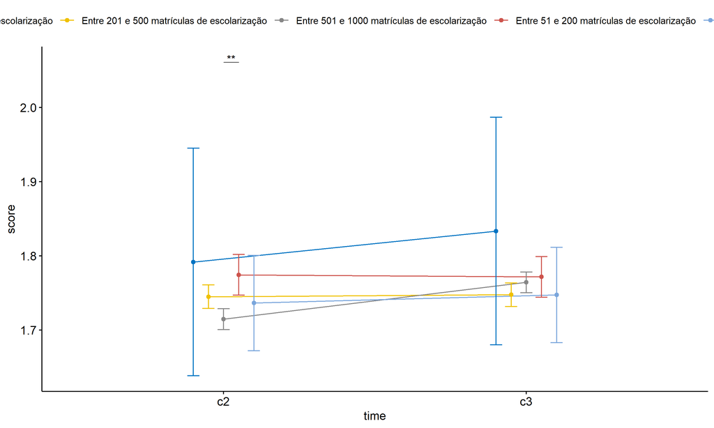

```r
if (length(non.ids) > 0) {
  pwc2 <- add_xy_position(pwc2, x = "time", fun = "mean_se", dodge = 0.25)
  pd2 <- position_dodge(width = 0.25)

  ggline(emms2, x = "time", y = "emmean", color = "porte",
         palette = c("#0073C2FF","#EFC000FF","#868686FF","#CD534CFF","#7AA6DCFF"),
         position = pd, ylab = "score") +
    geom_errorbar(aes(ymin = conf.low, ymax = conf.high, color = porte),
                position = pd, width = 0.2) +
    stat_pvalue_manual(pwc2, hide.ns = T, tip.length = F, linetype = 1)
}
```

```r
if (length(non.ids) > 0)
  (pwc2 <- ldat2 %>% group_by(porte) %>%
     emmeans_test(score ~ time, detailed = T, p.adjust.method = "bonferroni"))
```

```
## # A tibble: 5 × 15
##   porte      term  .y.   group1 group2 null.value estimate     se    df conf.low
## * <fct>      <chr> <chr> <chr>  <chr>       <dbl>    <dbl>  <dbl> <dbl>    <dbl>
## 1 Até 50 ma… time  score c2     c3              0 -0.0417  0.111   8028  -0.258
## 2 Entre 201… time  score c2     c3              0 -0.00273 0.0115  8028  -0.0252
## 3 Entre 501… time  score c2     c3              0 -0.0495  0.0101  8028  -0.0693
## 4 Entre 51 … time  score c2     c3              0  0.00277 0.0197  8028  -0.0359
## 5 Mais de 1… time  score c2     c3              0 -0.0110  0.0464  8028  -0.102
## # ℹ 5 more variables: conf.high <dbl>, statistic <dbl>, p <dbl>, p.adj <dbl>,
## #   p.adj.signif <chr>
```

| porte | term | .y. | group1 | group2 | null.value | estimate | se | df | conf.low | conf.high | statistic | p | p.adj | p.adj.signif |
| --- | --- | --- | --- | --- | --- | --- | --- | --- | --- | --- | --- | --- | --- | --- |
| Até 50 matrículas de escolarização | time | score | c2 | c3 | 0 | -0.042 | 0.111 | 8028 | -0.258 | 0.175 | -0.377 | 0.706 | 0.706 | ns |
| Entre 201 e 500 matrículas de escolarização | time | score | c2 | c3 | 0 | -0.003 | 0.011 | 8028 | -0.025 | 0.020 | -0.238 | 0.812 | 0.812 | ns |
| Entre 501 e 1000 matrículas de escolarização | time | score | c2 | c3 | 0 | -0.050 | 0.010 | 8028 | -0.069 | -0.030 | -4.906 | 0.000 | 0.000 | **** |
| Entre 51 e 200 matrículas de escolarização | time | score | c2 | c3 | 0 | 0.003 | 0.020 | 8028 | -0.036 | 0.041 | 0.140 | 0.889 | 0.889 | ns |
| Mais de 1000 matrículas de escolarização | time | score | c2 | c3 | 0 | -0.011 | 0.046 | 8028 | -0.102 | 0.080 | -0.237 | 0.813 | 0.813 | ns |

```r
if (length(non.ids) > 0)
  (emms2 <- get_emmeans(pwc2))
```

```
## # A tibble: 10 × 8
##    porte                    time  emmean      se    df conf.low conf.high method
##    <fct>                    <fct>  <dbl>   <dbl> <dbl>    <dbl>     <dbl> <chr>
##  1 Até 50 matrículas de es… c2      1.79 0.0782   8028     1.64      1.94 Emmea…
##  2 Até 50 matrículas de es… c3      1.83 0.0782   8028     1.68      1.99 Emmea…
##  3 Entre 201 e 500 matrícu… c2      1.74 0.00811  8028     1.73      1.76 Emmea…
##  4 Entre 201 e 500 matrícu… c3      1.75 0.00811  8028     1.73      1.76 Emmea…
##  5 Entre 501 e 1000 matríc… c2      1.71 0.00714  8028     1.70      1.73 Emmea…
##  6 Entre 501 e 1000 matríc… c3      1.76 0.00714  8028     1.75      1.78 Emmea…
##  7 Entre 51 e 200 matrícul… c2      1.77 0.0140   8028     1.75      1.80 Emmea…
##  8 Entre 51 e 200 matrícul… c3      1.77 0.0140   8028     1.74      1.80 Emmea…
##  9 Mais de 1000 matrículas… c2      1.74 0.0328   8028     1.67      1.80 Emmea…
## 10 Mais de 1000 matrículas… c3      1.75 0.0328   8028     1.68      1.81 Emmea…
```

| porte | time | emmean | se | df | conf.low | conf.high | method |
| --- | --- | --- | --- | --- | --- | --- | --- |
| Até 50 matrículas de escolarização | c2 | 1.792 | 0.078 | 8028 | 1.638 | 1.945 | Emmeans test |
| Até 50 matrículas de escolarização | c3 | 1.833 | 0.078 | 8028 | 1.680 | 1.987 | Emmeans test |
| Entre 201 e 500 matrículas de escolarização | c2 | 1.745 | 0.008 | 8028 | 1.729 | 1.761 | Emmeans test |
| Entre 201 e 500 matrículas de escolarização | c3 | 1.748 | 0.008 | 8028 | 1.732 | 1.763 | Emmeans test |
| Entre 501 e 1000 matrículas de escolarização | c2 | 1.715 | 0.007 | 8028 | 1.701 | 1.729 | Emmeans test |
| Entre 501 e 1000 matrículas de escolarização | c3 | 1.764 | 0.007 | 8028 | 1.750 | 1.778 | Emmeans test |
| Entre 51 e 200 matrículas de escolarização | c2 | 1.774 | 0.014 | 8028 | 1.747 | 1.802 | Emmeans test |
| Entre 51 e 200 matrículas de escolarização | c3 | 1.772 | 0.014 | 8028 | 1.744 | 1.799 | Emmeans test |
| Mais de 1000 matrículas de escolarização | c2 | 1.736 | 0.033 | 8028 | 1.672 | 1.801 | Emmeans test |
| Mais de 1000 matrículas de escolarização | c3 | 1.747 | 0.033 | 8028 | 1.683 | 1.812 | Emmeans test |

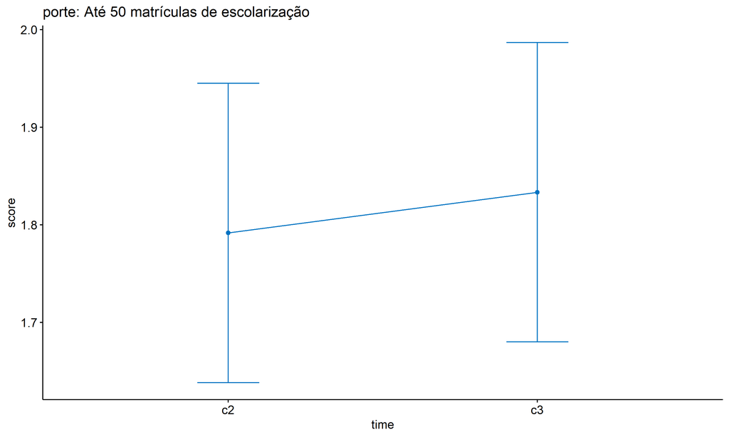

```r
if (length(non.ids) > 0) {
  emms.gg <- emms2[which(emms2$porte == "Até 50 matrículas de escolarização"),]
  if (nrow(emms.gg) > 0)
    ggline(emms.gg, x = "time", y = "emmean", color = "#0073C2FF", ylab = "score") +
    geom_errorbar(aes(ymin = conf.low, ymax = conf.high),
                  width = 0.2, color = "#0073C2FF") +
    stat_pvalue_manual(
      add_xy_position(pwc[which(pwc$porte == "Até 50 matrículas de escolarização"),],
                      x = "time", fun = "mean_se"),
      hide.ns = T, color = "#0073C2FF", tip.length = F) +
    labs(title = "porte: Até 50 matrículas de escolarização") +
    theme(legend.text = element_blank())
}
```

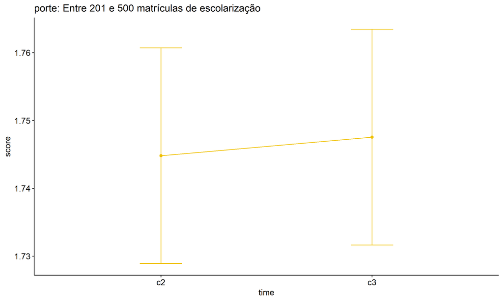

```r
if (length(non.ids) > 0) {
  emms.gg <- emms2[which(emms2$porte == "Entre 201 e 500 matrículas de escolarização"),]
  if (nrow(emms.gg) > 0)
    ggline(emms.gg, x = "time", y = "emmean", color = "#EFC000FF", ylab = "score") +
    geom_errorbar(aes(ymin = conf.low, ymax = conf.high),
                  width = 0.2, color = "#EFC000FF") +
    stat_pvalue_manual(
      add_xy_position(pwc[which(pwc$porte == "Entre 201 e 500 matrículas de escolarização"),],
                      x = "time", fun = "mean_se"),
      hide.ns = T, color = "#EFC000FF", tip.length = F) +
    labs(title = "porte: Entre 201 e 500 matrículas de escolarização") +
    theme(legend.text = element_blank())
}
```

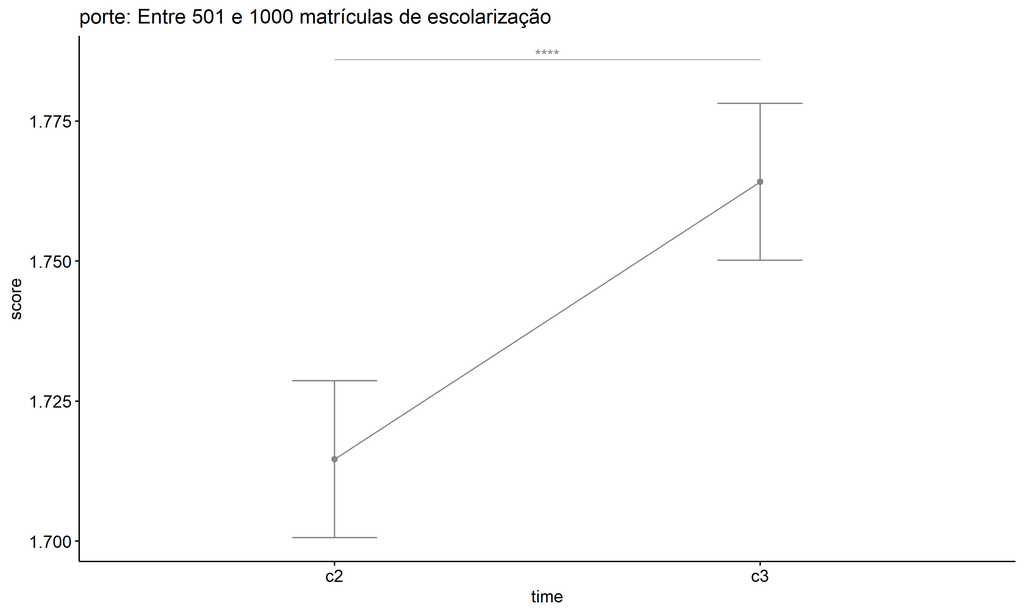

```r
if (length(non.ids) > 0) {
  emms.gg <- emms2[which(emms2$porte == "Entre 501 e 1000 matrículas de escolarização"),]
  if (nrow(emms.gg) > 0)
    ggline(emms.gg, x = "time", y = "emmean", color = "#868686FF", ylab = "score") +
    geom_errorbar(aes(ymin = conf.low, ymax = conf.high),
                  width = 0.2, color = "#868686FF") +
    stat_pvalue_manual(
      add_xy_position(pwc[which(pwc$porte == "Entre 501 e 1000 matrículas de escolarização"),],
                      x = "time", fun = "mean_se"),
      hide.ns = T, color = "#868686FF", tip.length = F) +
    labs(title = "porte: Entre 501 e 1000 matrículas de escolarização") +
    theme(legend.text = element_blank())
}
```

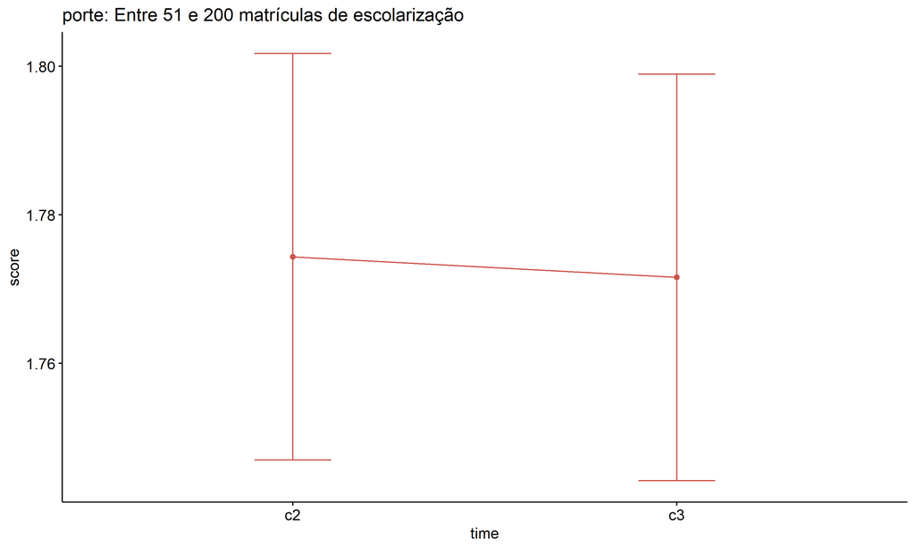

```r
if (length(non.ids) > 0) {
  emms.gg <- emms2[which(emms2$porte == "Entre 51 e 200 matrículas de escolarização"),]
  if (nrow(emms.gg) > 0)
    ggline(emms.gg, x = "time", y = "emmean", color = "#CD534CFF", ylab = "score") +
    geom_errorbar(aes(ymin = conf.low, ymax = conf.high),
                  width = 0.2, color = "#CD534CFF") +
    stat_pvalue_manual(
      add_xy_position(pwc[which(pwc$porte == "Entre 51 e 200 matrículas de escolarização"),],
                      x = "time", fun = "mean_se"),
      hide.ns = T, color = "#CD534CFF", tip.length = F) +
    labs(title = "porte: Entre 51 e 200 matrículas de escolarização") +
    theme(legend.text = element_blank())
}
```

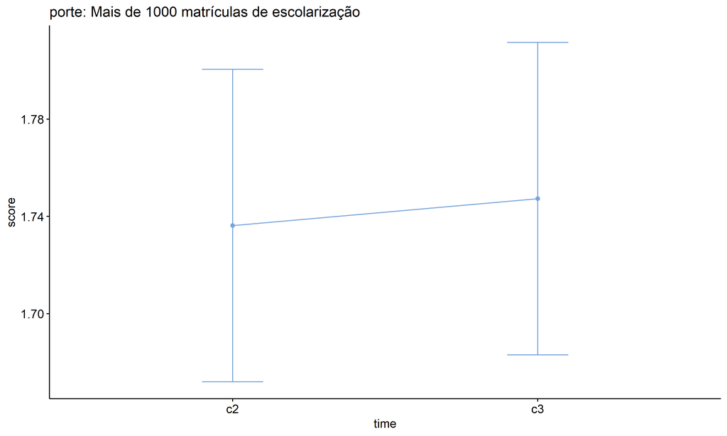

```r
if (length(non.ids) > 0) {
  emms.gg <- emms2[which(emms2$porte == "Mais de 1000 matrículas de escolarização"),]
  if (nrow(emms.gg) > 0)
    ggline(emms.gg, x = "time", y = "emmean", color = "#7AA6DCFF", ylab = "score") +
    geom_errorbar(aes(ymin = conf.low, ymax = conf.high),
                  width = 0.2, color = "#7AA6DCFF") +
    stat_pvalue_manual(
      add_xy_position(pwc[which(pwc$porte == "Mais de 1000 matrículas de escolarização"),],
                      x = "time", fun = "mean_se"),
      hide.ns = T, color = "#7AA6DCFF", tip.length = F) +
    labs(title = "porte: Mais de 1000 matrículas de escolarização") +
    theme(legend.text = element_blank())
}
```